# Project

2022-12-03

load package

```r
library(fpp2)
library(TSA)
library(aod)
library(urca)
library(tseries)
library(mgcv)
library(vars)
library(lmtest)
```

read data

```r
hosr <- read.csv("~/hosr_var.csv")
#setwd("C:/Users/emrqyw7/OneDrive - McKesson Corporation/Training/OMSCS/tsa/tsa_code/project")
#hosr <- read.csv("data/hosr_var.csv")
n <- length(hosr$hosr)
hosr_log <- log(subset(hosr,select = -c(year,date,quarter)))
# set last 15 data points as testing
training <- hosr[1:(n-15),]
testing <- hosr[(n-14):n,]
# log transformation
training_log <- hosr_log[1:(n-15),]
testing_log <- hosr_log[(n-14):n,]
n
```

```
## [1] 168
```

```r
ts_hosr <-ts(hosr["hosr"],start = 1980, freq = 4)
ts_fedfunds <-ts(hosr["FEDFUNDS"],start = 1980, freq = 4)
ts_mspus <-ts(hosr["MSPUS"],start = 1980, freq = 4)
ts_gdp <-ts(hosr["GDPC1"],start = 1980, freq = 4)
ts_payem <-ts(hosr["PAYEMS"],start = 1980, freq = 4)
ts_cpi <-ts(hosr["CPIAUCSL"],start = 1980, freq = 4)
ts_unrate <-ts(hosr["UNRATE"],start = 1980, freq = 4)
ts_umcsent <-ts(hosr["UMCSENT"],start = 1980, freq = 4)
ts_dispic <-ts(hosr["DSPIC96"],start = 1980, freq = 4)
ts_permit <-ts(hosr["PERMIT"],start = 1980, freq = 4)
ts_icsa <-ts(hosr["ICSA"],start = 1980, freq = 4)
ts_sp500 <-ts(hosr["SP500"],start = 1980, freq = 4)
ts_hosr_log <-ts(hosr_log["hosr"],start = 1980, freq = 4)
ts_fedfunds_log <-ts(hosr_log["FEDFUNDS"],start = 1980, freq = 4)
ts_mspus_log <-ts(hosr_log["MSPUS"],start = 1980, freq = 4)
ts_gdp_log <-ts(hosr_log["GDPC1"],start = 1980, freq = 4)
ts_payem_log <-ts(hosr_log["PAYEMS"],start = 1980, freq = 4)
ts_cpi_log <-ts(hosr_log["CPIAUCSL"],start = 1980, freq = 4)
ts_unrate_log <-ts(hosr_log["UNRATE"],start = 1980, freq = 4)
ts_umcsent_log <-ts(hosr_log["UMCSENT"],start = 1980, freq = 4)
ts_dispic_log <-ts(hosr_log["DSPIC96"],start = 1980, freq = 4)
ts_permit_log <-ts(hosr_log["PERMIT"],start = 1980, freq = 4)
ts_icsa_log <-ts(hosr_log["ICSA"],start = 1980, freq = 4)
ts_sp500_log <-ts(hosr_log["SP500"],start = 1980, freq = 4)
```

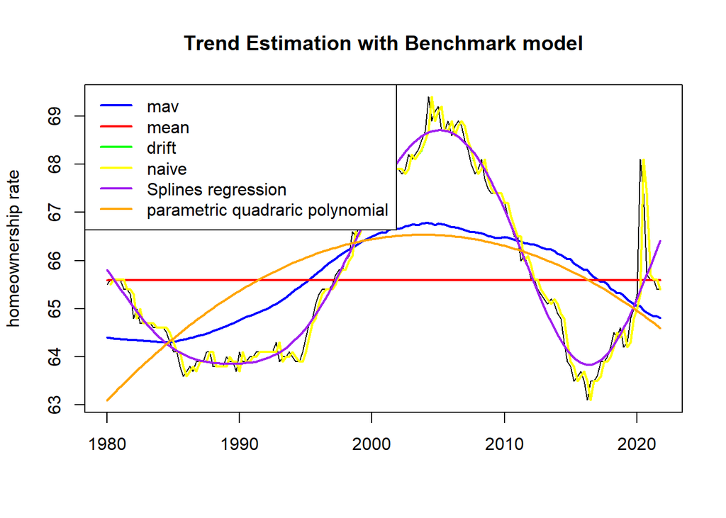

```r
### Benchmark models
# Original data
points <- 1:length(hosr$date)
points <- (points - min(points))/max(points)
# 1. Fit a moving average model
mav_model <- ksmooth(points, hosr$hosr, kernel = "box")
mav_fit <- ts(mav_model$y, start = 1980, frequency = 4)
# 2. Fit mean model
mean_model <- meanf(ts_hosr)
mean_fit <- ts(mean_model$fitted, start = 1980, frequency = 4)
# 3. Fit drift model
drift_model <- rwf(ts_hosr,12,drift=TRUE)
drift_fit <- ts(drift_model$fitted, start = 1980, frequency = 4)
# 4. Fit naive model
naive_model <- naive(ts_hosr,12)
naive_fit <- ts(naive_model$fitted, start = 1980, frequency = 4)
# Splines Trend Estimation
gam_model <- gam(ts_hosr~s(points))
gam_fit <- ts(fitted(gam_model),start=1980,frequency=4)
#parametric quadraric polynomial
x1 = points
x2 =points^2
para_model = lm(ts_hosr~x1+x2)
para_fit = ts(fitted(para_model),start=1980,frequency=4)
# plot
ts.plot(ts_hosr,xlab="",ylab="homeownership rate",main = "Trend Estimation with Benchmark model")
lines(mav_fit,lwd=2,col="blue")
lines(mean_fit,lwd=2,col="red")
lines(drift_fit,lwd=2,col="green")
lines(naive_fit,lwd=2,col="yellow")
lines(gam_fit,lwd=2,col="purple")
lines(para_fit,lwd=2,col="orange")
legend("topleft", legend = c("mav", "mean", "drift", "naive","Splines regression","parametric quadraric polynomial"),
       col = c("blue", "red", "green", "yellow","purple","orange"), lwd = 2)
```

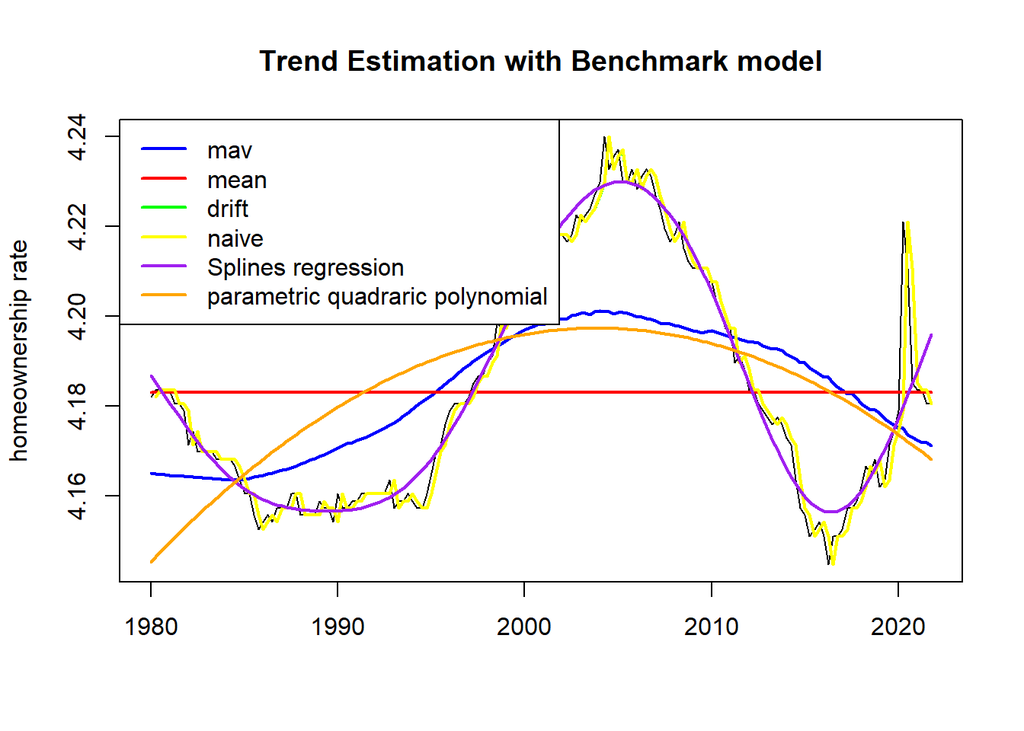

```r
# Log Data
# 1. Fit a moving average model
mav_model_log <- ksmooth(points, ts_hosr_log, kernel = "box")
mav_fit_log <- ts(mav_model_log$y, start = 1980, frequency = 4)
# 2. Fit mean model
mean_model_log <- meanf(ts_hosr_log)
mean_fit_log <- ts(mean_model_log$fitted, start = 1980, frequency = 4)
# 3. Fit drift model
drift_model_log <- rwf(ts_hosr_log,12,drift=TRUE)
drift_fit_log <- ts(drift_model_log$fitted, start = 1980, frequency = 4)
# 4. Fit naive model
naive_model_log <- naive(ts_hosr_log,12)
naive_fit_log <- ts(naive_model_log$fitted, start = 1980, frequency = 4)
# Splines Trend Estimation
gam_model_log <- gam(ts_hosr_log~s(points))
gam_fit_log <- ts(fitted(gam_model_log),start=1980,frequency=4)
#parametric quadraric polynomial
x1 = points
x2 =points^2
para_model_log = lm(ts_hosr_log~x1+x2)
para_fit_log = ts(fitted(para_model_log),start=1980,frequency=4)
# plot
ts.plot(ts_hosr_log,xlab="",ylab="homeownership rate",main = "Trend Estimation with Benchmark model")
lines(mav_fit_log,lwd=2,col="blue")
lines(mean_fit_log,lwd=2,col="red")
lines(drift_fit_log,lwd=2,col="green")
lines(naive_fit_log,lwd=2,col="yellow")
lines(gam_fit_log,lwd=2,col="purple")
lines(para_fit_log,lwd=2,col="orange")
legend("topleft", legend = c("mav", "mean", "drift", "naive","Splines regression","parametric quadraric polynomial"),
       col = c("blue", "red", "green", "yellow","purple","orange"), lwd = 2)
```

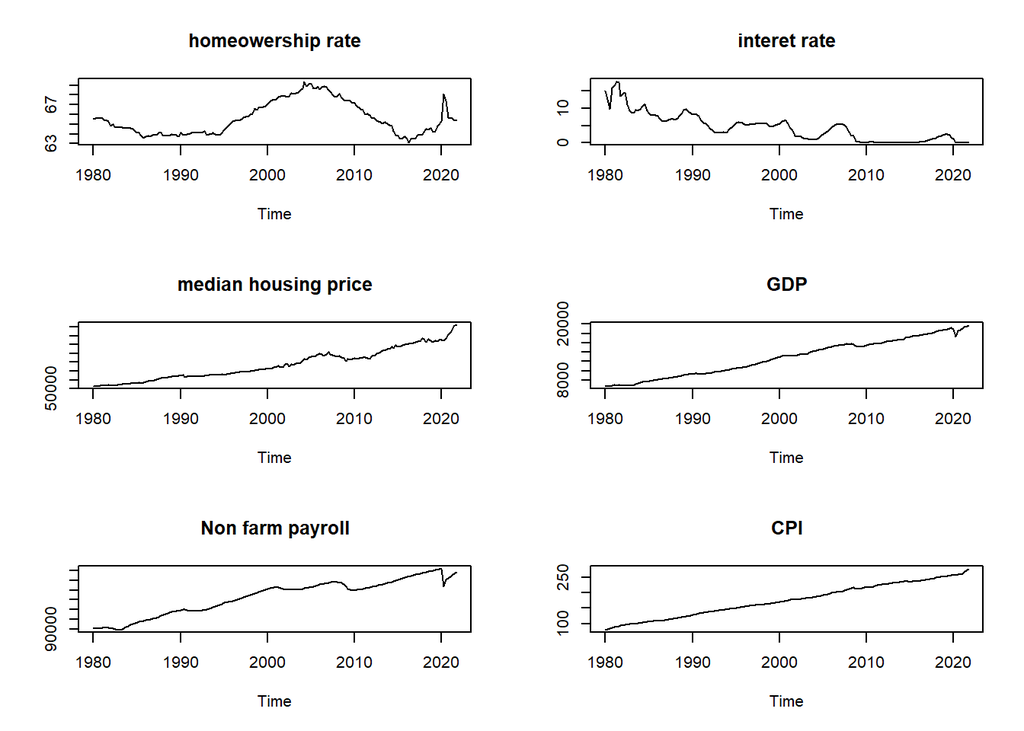

```r
par(mfrow=c(3,2))
plot(ts_hosr, type="l", main=paste("homeowership rate"),ylab="")
plot(ts_fedfunds, type="l", main=paste("interet rate"),ylab="")
plot(ts_mspus, type="l", main=paste("median housing price"),ylab="")
plot(ts_gdp, type="l", main=paste("GDP"),ylab="")
plot(ts_payem, type="l", main=paste("Non farm payroll"),ylab="")
plot(ts_cpi, type="l", main=paste("CPI"),ylab="")
```

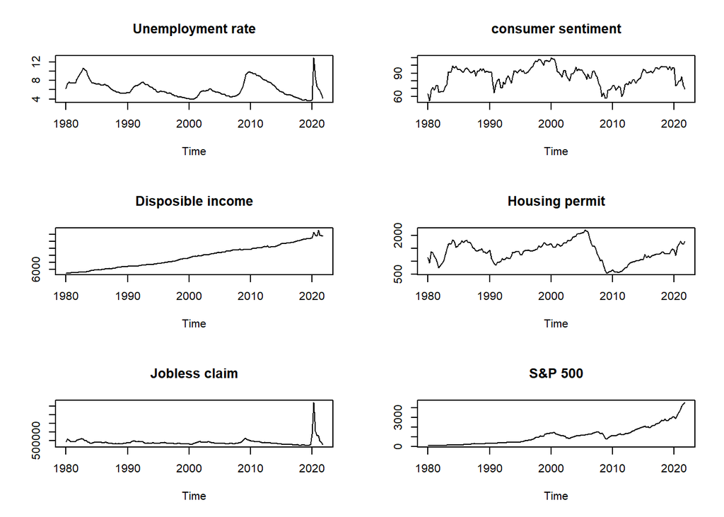

```r
plot(ts_unrate, type="l", main=paste("Unemployment rate"),ylab="")
plot(ts_umcsent, type="l", main=paste("consumer sentiment"),ylab="")
plot(ts_dispic, type="l", main=paste("Disposible income"),ylab="")
plot(ts_permit, type="l", main=paste("Housing permit"),ylab="")
plot(ts_icsa, type="l", main=paste("Jobless claim"),ylab="")
plot(ts_sp500, type="l", main=paste("S&P 500"),ylab="")
```

Housing permit and consumer sentiment seems to have a very similar pattern as the home ownership rate, while interest rate might exhibit negative relationship with homeowership rate. Log transformation might be needed variables like Non farm payroll, median housing price for them to show more clear correlation with the target.

##1st Order Time Series##

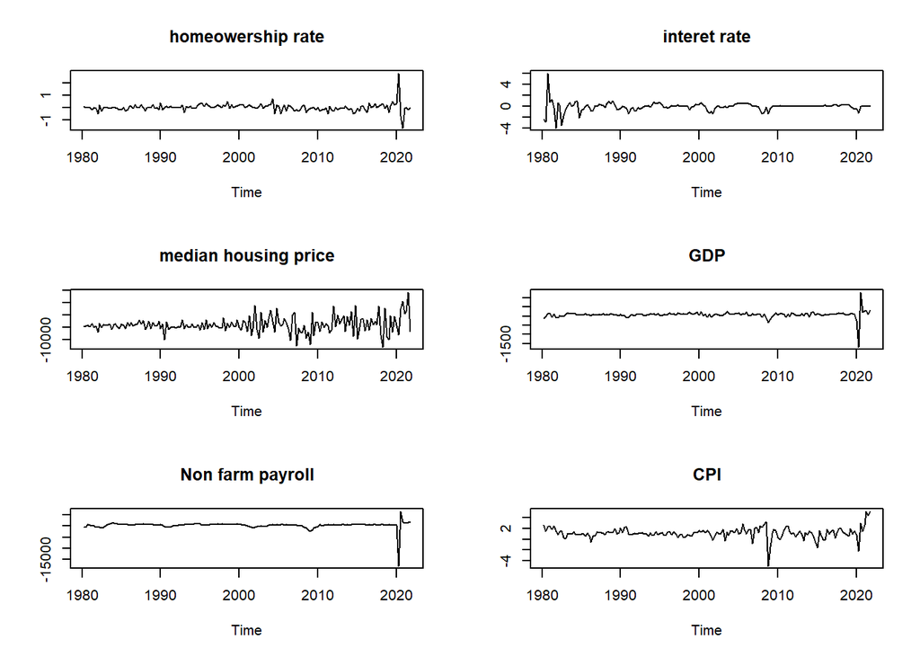

```r
par(mfrow=c(3,2))
plot(diff(ts_hosr), type="l", main=paste("homeowership rate"),ylab="")
plot(diff(ts_fedfunds), type="l", main=paste("interet rate"),ylab="")
plot(diff(ts_mspus), type="l", main=paste("median housing price"),ylab="")
plot(diff(ts_gdp), type="l", main=paste("GDP"),ylab="")
plot(diff(ts_payem), type="l", main=paste("Non farm payroll"),ylab="")
plot(diff(ts_cpi), type="l", main=paste("CPI"),ylab="")
```

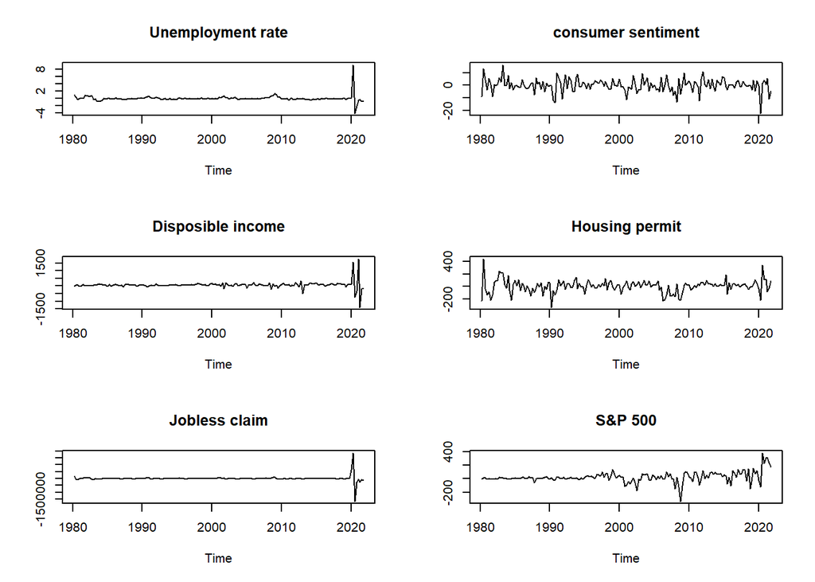

```r
plot(diff(ts_unrate), type="l", main=paste("Unemployment rate"),ylab="")
plot(diff(ts_umcsent), type="l", main=paste("consumer sentiment"),ylab="")
plot(diff(ts_dispic), type="l", main=paste("Disposible income"),ylab="")
plot(diff(ts_permit), type="l", main=paste("Housing permit"),ylab="")
plot(diff(ts_icsa), type="l", main=paste("Jobless claim"),ylab="")
plot(diff(ts_sp500), type="l", main=paste("S&P 500"),ylab="")
```

ACF and PACF

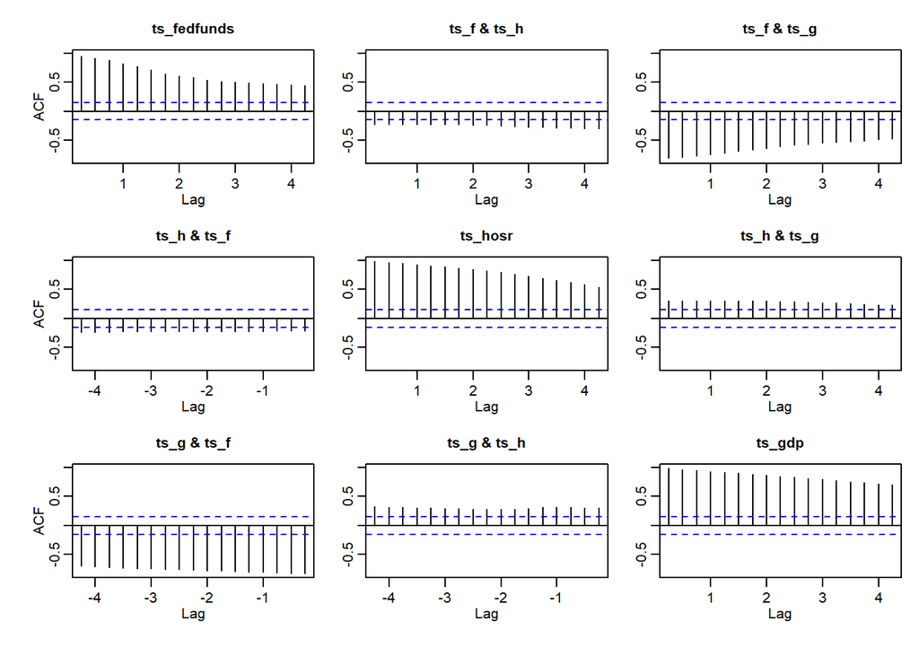

```r
data.ts = ts.union(ts_fedfunds,ts_hosr,ts_gdp)
plot(acf(data.ts,plot=FALSE),mar=c(3.5,3,1.9,0))
```

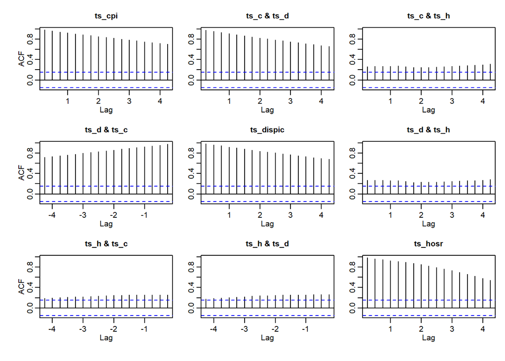

```r
data.ts = ts.union(ts_cpi,ts_dispic,ts_hosr)
plot(acf(data.ts,plot=FALSE),mar=c(3.5,3,1.9,0))
```

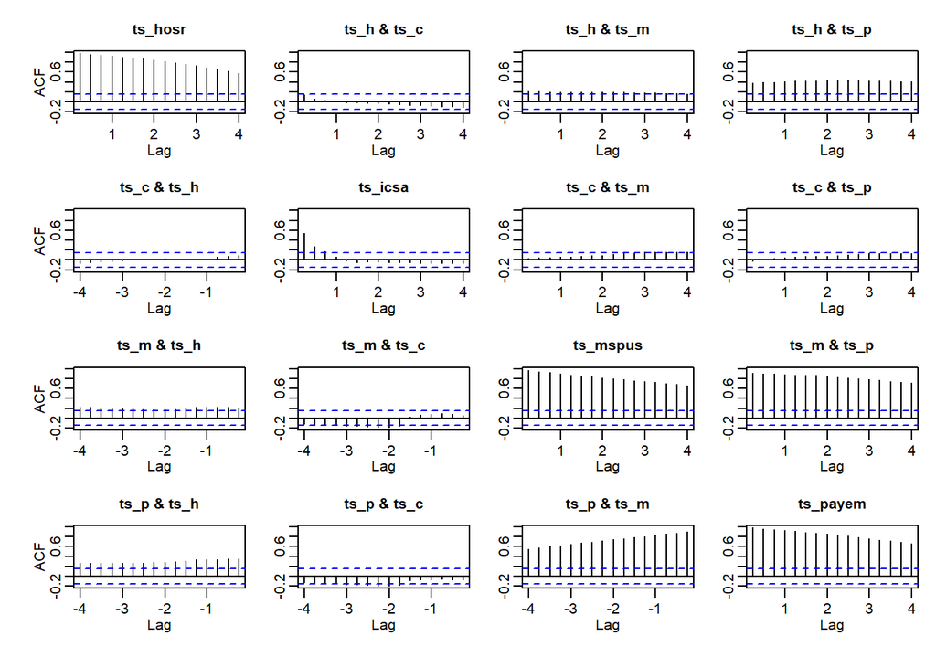

```r
data.ts = ts.union(ts_hosr,ts_icsa,ts_mspus,ts_payem)
plot(acf(data.ts,plot=FALSE),mar=c(3.5,3,1.9,0))
```

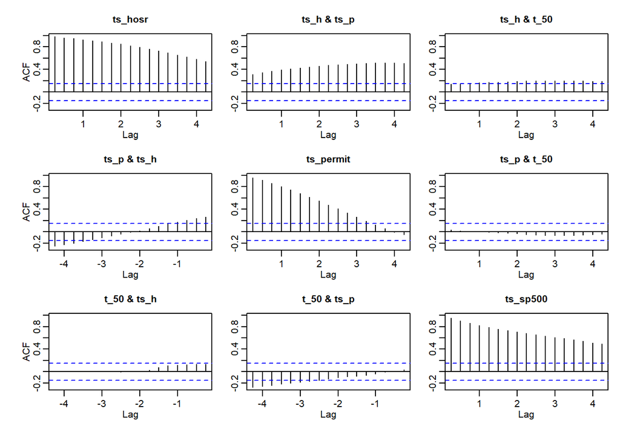

```r
data.ts = ts.union(ts_hosr,ts_permit,ts_sp500)
plot(acf(data.ts,plot=FALSE),mar=c(3.5,3,1.9,0))
```

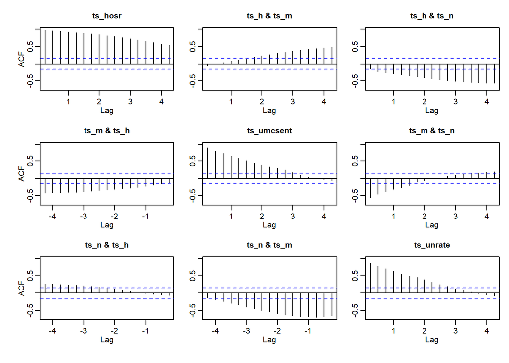

```r
data.ts = ts.union(ts_hosr,ts_umcsent,ts_unrate)
plot(acf(data.ts,plot=FALSE),mar=c(3.5,3,1.9,0))
```

Granger Causality: Wald test

```r
var_data <- cbind(ts_hosr,ts_cpi,ts_dispic,ts_fedfunds,ts_gdp,ts_icsa,ts_mspus,ts_payem,ts_permit,ts_sp500,ts_umcsent,ts_unrate)
VARselect(var_data, lag.max = 21)$selection
```

```
## AIC(n)  HQ(n)  SC(n) FPE(n)
##     13     13     13     13
```

```r
model.var=VAR(var_data, p=10)
summary(model.var$varresult$ts_hosr)
```

```
##
## Call:
## lm(formula = y ~ -1 + ., data = datamat)
##
## Residuals:
##       Min        1Q    Median        3Q       Max
## -0.177772 -0.054600 -0.003347  0.038866  0.264911
##
## Coefficients:
##                   Estimate Std. Error t value Pr(>|t|)
## ts_hosr.l1       5.468e-01  1.823e-01   2.999 0.004817 **
## ts_cpi.l1        8.414e-02  5.726e-02   1.469 0.150180
## ts_dispic.l1    -5.728e-04  3.677e-04  -1.558 0.127793
## ts_fedfunds.l1   1.904e-01  9.657e-02   1.972 0.056108 .
## ts_gdp.l1       -1.084e-03  7.825e-04  -1.385 0.174256
## ts_icsa.l1       3.373e-06  7.938e-07   4.250 0.000139 ***
## ts_mspus.l1     -1.417e-05  6.163e-06  -2.299 0.027249 *
## ts_payem.l1      8.409e-05  1.447e-04   0.581 0.564676
## ts_permit.l1     1.417e-03  3.771e-04   3.757 0.000592 ***
## ts_sp500.l1      8.269e-04  7.129e-04   1.160 0.253491
## ts_umcsent.l1   -2.289e-03  8.379e-03  -0.273 0.786222
## ts_unrate.l1    -4.144e-01  2.296e-01  -1.805 0.079215 .
## ts_hosr.l2       8.433e-02  2.031e-01   0.415 0.680327
## ts_cpi.l2       -3.999e-02  7.532e-02  -0.531 0.598646
## ts_dispic.l2     2.073e-05  4.324e-04   0.048 0.962020
## ts_fedfunds.l2  -1.329e-01  1.209e-01  -1.099 0.278784
## ts_gdp.l2        9.197e-04  7.605e-04   1.209 0.234246
## ts_icsa.l2      -4.953e-06  1.771e-06  -2.796 0.008160 **
## ts_mspus.l2     -3.308e-06  5.856e-06  -0.565 0.575611
## ts_payem.l2     -3.490e-04  1.563e-04  -2.233 0.031695 *
## ts_permit.l2    -1.092e-04  4.584e-04  -0.238 0.813093
## ts_sp500.l2     -5.101e-04  7.262e-04  -0.702 0.486806
## ts_umcsent.l2    2.440e-03  9.514e-03   0.256 0.799000
## ts_unrate.l2     5.207e-01  2.593e-01   2.008 0.051973 .
## ts_hosr.l3       7.981e-02  2.181e-01   0.366 0.716531
## ts_cpi.l3        3.409e-02  6.868e-02   0.496 0.622628
## ts_dispic.l3    -3.253e-04  3.921e-04  -0.830 0.412091
## ts_fedfunds.l3   3.493e-02  1.078e-01   0.324 0.747798
## ts_gdp.l3        6.776e-04  8.044e-04   0.842 0.405049
## ts_icsa.l3       9.024e-07  2.532e-06   0.356 0.723553
```

[output cut: 82 more lines]

```
## ts_gdp.l10       3.217e-04  6.999e-04   0.460 0.648462
## ts_icsa.l10      3.864e-06  1.892e-06   2.042 0.048315 *
## ts_mspus.l10    -3.516e-06  8.305e-06  -0.423 0.674466
## ts_payem.l10     1.175e-04  2.314e-04   0.508 0.614594
## ts_permit.l10   -2.755e-04  4.005e-04  -0.688 0.495850
## ts_sp500.l10     4.012e-04  8.139e-04   0.493 0.624959
## ts_umcsent.l10   5.181e-03  9.484e-03   0.546 0.588133
## ts_unrate.l10   -8.840e-02  2.415e-01  -0.366 0.716397
## const            3.560e+01  1.228e+01   2.899 0.006254 **
## ---
## Signif. codes:  0 '***' 0.001 '**' 0.01 '*' 0.05 '.' 0.1 ' ' 1
##
## Residual standard error: 0.1689 on 37 degrees of freedom
## Multiple R-squared:  0.9978, Adjusted R-squared:  0.9907
## F-statistic:   141 on 120 and 37 DF,  p-value: < 2.2e-16
```

```r
## Model Fitting: Restricted VAR
model.var.restrict=restrict(model.var)
summary(model.var.restrict$varresult$ts_hosr)
```

```
##
## Call:
## lm(formula = y ~ -1 + ., data = datares)
##
## Residuals:
##       Min        1Q    Median        3Q       Max
## -0.279424 -0.074116  0.005775  0.063621  0.241304
##
## Coefficients:
##                  Estimate Std. Error t value Pr(>|t|)
## ts_hosr.l1      5.943e-01  4.837e-02  12.286  < 2e-16 ***
## ts_cpi.l1       7.686e-02  1.670e-02   4.603 1.18e-05 ***
## ts_dispic.l1   -5.641e-04  1.615e-04  -3.494 0.000700 ***
## ts_fedfunds.l1  1.468e-01  3.188e-02   4.604 1.18e-05 ***
## ts_gdp.l1      -6.930e-04  2.723e-04  -2.545 0.012410 *
## ts_icsa.l1      3.158e-06  3.017e-07  10.467  < 2e-16 ***
## ts_mspus.l1    -1.362e-05  2.341e-06  -5.818 6.63e-08 ***
## ts_permit.l1    1.119e-03  1.430e-04   7.825 4.42e-12 ***
## ts_unrate.l1   -5.153e-01  5.415e-02  -9.517 8.07e-16 ***
## ts_cpi.l2      -4.581e-02  1.658e-02  -2.763 0.006770 **
## ts_fedfunds.l2 -9.103e-02  4.107e-02  -2.216 0.028845 *
## ts_gdp.l2       8.337e-04  2.957e-04   2.819 0.005764 **
## ts_icsa.l2     -4.305e-06  4.841e-07  -8.892 1.99e-14 ***
## ts_payem.l2    -2.960e-04  4.994e-05  -5.927 4.05e-08 ***
## ts_unrate.l2    5.290e-01  8.176e-02   6.470 3.27e-09 ***
## ts_fedfunds.l3  8.415e-02  3.075e-02   2.736 0.007305 **
## ts_mspus.l3    -6.031e-06  2.646e-06  -2.279 0.024700 *
## ts_payem.l3     2.458e-04  2.336e-05  10.523  < 2e-16 ***
## ts_permit.l3    5.329e-04  1.574e-04   3.387 0.000999 ***
## ts_sp500.l3     4.948e-04  1.720e-04   2.877 0.004869 **
## ts_umcsent.l3  -8.579e-03  3.186e-03  -2.692 0.008271 **
## ts_dispic.l4   -3.976e-04  1.658e-04  -2.398 0.018285 *
## ts_icsa.l4      2.355e-06  3.281e-07   7.177 1.09e-10 ***
## ts_unrate.l4   -4.525e-01  6.500e-02  -6.962 3.12e-10 ***
## ts_dispic.l5    4.493e-04  1.556e-04   2.888 0.004721 **
## ts_mspus.l5    -9.036e-06  2.607e-06  -3.466 0.000768 ***
## ts_umcsent.l5  -1.539e-02  3.257e-03  -4.724 7.26e-06 ***
## ts_hosr.l6      1.780e-01  6.693e-02   2.660 0.009056 **
## ts_fedfunds.l6 -7.532e-02  2.326e-02  -3.238 0.001615 **
## ts_gdp.l6       5.200e-04  2.578e-04   2.017 0.046230 *
```

[output cut: 15 more lines]

```
## ts_cpi.l9      -5.791e-02  1.764e-02  -3.284 0.001395 **
## ts_dispic.l9    3.814e-04  1.647e-04   2.315 0.022553 *
## ts_gdp.l9       8.267e-04  2.495e-04   3.313 0.001269 **
## ts_mspus.l9     1.019e-05  2.294e-06   4.443 2.22e-05 ***
## ts_payem.l9     2.780e-04  4.948e-05   5.619 1.62e-07 ***
## ts_sp500.l9     6.013e-04  2.657e-04   2.263 0.025713 *
## ts_cpi.l10      4.531e-02  1.673e-02   2.708 0.007908 **
## ts_icsa.l10     3.883e-06  4.689e-07   8.281 4.47e-13 ***
## const           2.694e+01  3.286e+00   8.199 6.77e-13 ***
## ---
## Signif. codes:  0 '***' 0.001 '**' 0.01 '*' 0.05 '.' 0.1 ' ' 1
##
## Residual standard error: 0.1233 on 104 degrees of freedom
## Multiple R-squared:      1,  Adjusted R-squared:      1
## F-statistic: 8.287e+05 on 54 and 104 DF,  p-value: < 2.2e-16
```

```r
coef.hosr = coefficients(model.var)$ts_hosr[-(12*10+1),1]
var.model = vcov(model.var)[2:121,2:121]
## Granger Causality: CPI
print("CPI")
```

```
## [1] "CPI"
```

```r
wald.test(b=coef.hosr, var.model, Terms=seq(2, 12*10, 12))
```

```
## Wald test:
## ----------
##
## Chi-squared test:
## X2 = 6.5, df = 10, P(> X2) = 0.77
```

```r
## Granger Causality: disposible income
print("disposible income")
```

```
## [1] "disposible income"
```

```r
wald.test(b=coef.hosr, var.model, Terms=seq(3, 12*10, 12))
```

```
## Wald test:
## ----------
##
## Chi-squared test:
## X2 = 12.5, df = 10, P(> X2) = 0.25
```

```r
## Granger Causality: interet rate
print("interet rate")
```

```
## [1] "interet rate"
```

```r
wald.test(b=coef.hosr, var.model, Terms=seq(4, 12*10, 12))
```

```
## Wald test:
## ----------
##
## Chi-squared test:
## X2 = 9.1, df = 10, P(> X2) = 0.52
```

```r
## Granger Causality: gdp
print("gdp")
```

```
## [1] "gdp"
```

```r
wald.test(b=coef.hosr, var.model, Terms=seq(5, 12*10, 12))
```

```
## Wald test:
## ----------
##
## Chi-squared test:
## X2 = 10.8, df = 10, P(> X2) = 0.37
```

```r
## Granger Causality: innial claims
print("innial claims")
```

```
## [1] "innial claims"
```

```r
wald.test(b=coef.hosr, var.model, Terms=seq(6, 12*10, 12))
```

```
## Wald test:
## ----------
##
## Chi-squared test:
## X2 = 38.6, df = 10, P(> X2) = 2.9e-05
```

```r
## Granger Causality: median housing price
print("median housing price")
```

```
## [1] "median housing price"
```

```r
wald.test(b=coef.hosr, var.model, Terms=seq(7, 12*10, 12))
```

```
## Wald test:
## ----------
##
## Chi-squared test:
## X2 = 22.5, df = 10, P(> X2) = 0.013
```

```r
## Granger Causality: non farm payroll
print("non farm payroll")
```

```
## [1] "non farm payroll"
```

```r
wald.test(b=coef.hosr, var.model, Terms=seq(8, 12*10, 12))
```

```
## Wald test:
## ----------
##
## Chi-squared test:
## X2 = 11.9, df = 10, P(> X2) = 0.29
```

```r
## Granger Causality: housing permit
print("housing permit")
```

```
## [1] "housing permit"
```

```r
wald.test(b=coef.hosr, var.model, Terms=seq(9, 12*10, 12))
```

```
## Wald test:
## ----------
##
## Chi-squared test:
## X2 = 24.6, df = 10, P(> X2) = 0.0061
```

```r
## Granger Causality: sp500
print("sp500")
```

```
## [1] "sp500"
```

```r
wald.test(b=coef.hosr, var.model, Terms=seq(10, 12*10, 12))
```

```
## Wald test:
## ----------
##
## Chi-squared test:
## X2 = 10.1, df = 10, P(> X2) = 0.43
```

```r
## Granger Causality: consumer sentiments
print("consumer sentiments")
```

```
## [1] "consumer sentiments"
```

```r
wald.test(b=coef.hosr, var.model, Terms=seq(11, 12*10, 12))
```

```
## Wald test:
## ----------
##
## Chi-squared test:
## X2 = 10.5, df = 10, P(> X2) = 0.4
```

```r
## Granger Causality: unemployment rate
print("unemployment rate")
```

```
## [1] "unemployment rate"
```

```r
wald.test(b=coef.hosr, var.model, Terms=seq(12, 12*10, 12))
```

```
## Wald test:
## ----------
##
## Chi-squared test:
## X2 = 11.4, df = 10, P(> X2) = 0.33
```

granger causality test on log

```r
var_data <- cbind(ts_hosr_log,ts_cpi_log,ts_dispic_log,ts_fedfunds_log,ts_gdp_log,
                  ts_icsa_log,ts_mspus_log,ts_payem_log,ts_permit_log,ts_sp500_log,ts_umcsent_log,ts_unrate_log)
VARselect(var_data, lag.max = 21)$selection
```

```
## AIC(n)  HQ(n)  SC(n) FPE(n)
##     13     13     13     13
```

```r
model.var=VAR(var_data, p=10)
summary(model.var$varresult$ts_hosr)
```

```
##
## Call:
## lm(formula = y ~ -1 + ., data = datamat)
##
## Residuals:
##        Min         1Q     Median         3Q        Max
## -0.0031449 -0.0008313  0.0000237  0.0007758  0.0045666
##
## Coefficients:
##                       Estimate Std. Error t value Pr(>|t|)
## ts_hosr_log.l1       5.150e-01  1.957e-01   2.632  0.01231 *
## ts_cpi_log.l1        1.901e-01  1.316e-01   1.445  0.15696
## ts_dispic_log.l1    -1.873e-02  7.241e-02  -0.259  0.79730
## ts_fedfunds_log.l1   2.506e-04  3.319e-03   0.076  0.94020
## ts_gdp_log.l1       -1.461e-01  1.450e-01  -1.008  0.32021
## ts_icsa_log.l1       2.642e-02  4.979e-03   5.306 5.47e-06 ***
## ts_mspus_log.l1     -4.411e-03  1.859e-02  -0.237  0.81380
## ts_payem_log.l1     -3.650e-01  2.419e-01  -1.509  0.13989
## ts_permit_log.l1     1.604e-02  9.073e-03   1.768  0.08532 .
## ts_sp500_log.l1     -9.532e-04  1.032e-02  -0.092  0.92690
## ts_umcsent_log.l1   -4.875e-03  1.184e-02  -0.412  0.68296
## ts_unrate_log.l1    -6.717e-02  2.211e-02  -3.038  0.00435 **
## ts_hosr_log.l2       2.406e-01  2.104e-01   1.144  0.26012
## ts_cpi_log.l2       -4.146e-01  1.717e-01  -2.415  0.02080 *
## ts_dispic_log.l2    -9.250e-02  6.984e-02  -1.324  0.19348
## ts_fedfunds_log.l2   3.009e-03  4.342e-03   0.693  0.49270
## ts_gdp_log.l2        1.573e-01  1.467e-01   1.073  0.29038
## ts_icsa_log.l2      -2.582e-02  1.176e-02  -2.196  0.03441 *
## ts_mspus_log.l2     -7.617e-03  1.836e-02  -0.415  0.68062
## ts_payem_log.l2      2.284e-01  2.508e-01   0.911  0.36821
## ts_permit_log.l2    -6.239e-03  1.014e-02  -0.615  0.54225
## ts_sp500_log.l2      9.192e-03  1.158e-02   0.794  0.43220
## ts_umcsent_log.l2   -1.373e-02  1.138e-02  -1.207  0.23515
## ts_unrate_log.l2     4.438e-02  2.664e-02   1.666  0.10419
## ts_hosr_log.l3      -3.583e-02  1.893e-01  -0.189  0.85088
## ts_cpi_log.l3        2.558e-02  1.842e-01   0.139  0.89027
## ts_dispic_log.l3     4.712e-02  6.501e-02   0.725  0.47310
## ts_fedfunds_log.l3  -3.996e-04  4.300e-03  -0.093  0.92645
## ts_gdp_log.l3        6.944e-02  1.471e-01   0.472  0.63970
## ts_icsa_log.l3       1.376e-02  1.450e-02   0.949  0.34883
```

[output cut: 82 more lines]

```
## ts_gdp_log.l10      -2.958e-02  1.145e-01  -0.258  0.79753
## ts_icsa_log.l10      8.934e-03  1.283e-02   0.696  0.49062
## ts_mspus_log.l10    -2.206e-02  2.590e-02  -0.852  0.39976
## ts_payem_log.l10     8.242e-02  3.486e-01   0.236  0.81439
## ts_permit_log.l10    2.299e-03  8.078e-03   0.285  0.77751
## ts_sp500_log.l10    -7.232e-03  9.415e-03  -0.768  0.44727
## ts_umcsent_log.l10   1.361e-02  8.984e-03   1.515  0.13830
## ts_unrate_log.l10    1.912e-02  2.375e-02   0.805  0.42609
## const               -1.640e+00  1.860e+00  -0.882  0.38352
## ---
## Signif. codes:  0 '***' 0.001 '**' 0.01 '*' 0.05 '.' 0.1 ' ' 1
##
## Residual standard error: 0.002655 on 37 degrees of freedom
## Multiple R-squared:  0.9976, Adjusted R-squared:   0.99
## F-statistic: 130.6 on 120 and 37 DF,  p-value: < 2.2e-16
```

```r
## Model Fitting: Restricted VAR
model.var.restrict=restrict(model.var)
summary(model.var.restrict$varresult$ts_hosr)
```

```
##
## Call:
## lm(formula = y ~ -1 + ., data = datares)
##
## Residuals:
##        Min         1Q     Median         3Q        Max
## -0.0055739 -0.0011258 -0.0000826  0.0011379  0.0048440
##
## Coefficients:
##                      Estimate Std. Error t value Pr(>|t|)
## ts_hosr_log.l1      0.7220596  0.0459326  15.720  < 2e-16 ***
## ts_icsa_log.l1      0.0260718  0.0017212  15.147  < 2e-16 ***
## ts_unrate_log.l1   -0.0367826  0.0038048  -9.668  < 2e-16 ***
## ts_cpi_log.l2      -0.1825241  0.0293256  -6.224 6.72e-09 ***
## ts_fedfunds_log.l2  0.0024788  0.0006458   3.838 0.000196 ***
## ts_icsa_log.l2     -0.0102856  0.0018810  -5.468 2.37e-07 ***
## ts_umcsent_log.l2  -0.0131548  0.0036227  -3.631 0.000410 ***
## ts_payem_log.l3     0.0730756  0.0343901   2.125 0.035563 *
## ts_icsa_log.l4      0.0134325  0.0029448   4.561 1.20e-05 ***
## ts_permit_log.l4   -0.0050063  0.0016759  -2.987 0.003389 **
## ts_sp500_log.l4    -0.0084138  0.0020316  -4.142 6.30e-05 ***
## ts_dispic_log.l5    0.0752897  0.0246630   3.053 0.002771 **
## ts_gdp_log.l5      -0.1842351  0.0413645  -4.454 1.85e-05 ***
## ts_icsa_log.l5     -0.0231641  0.0037187  -6.229 6.56e-09 ***
## ts_umcsent_log.l5  -0.0191902  0.0039853  -4.815 4.17e-06 ***
## ts_hosr_log.l6      0.3634745  0.0759634   4.785 4.74e-06 ***
## ts_dispic_log.l6    0.0747249  0.0283883   2.632 0.009551 **
## ts_fedfunds_log.l6  0.0029582  0.0009355   3.162 0.001965 **
## ts_icsa_log.l6      0.0181002  0.0032203   5.621 1.18e-07 ***
## ts_payem_log.l6     0.2871912  0.0392895   7.310 2.80e-11 ***
## ts_hosr_log.l7     -0.2761308  0.0840363  -3.286 0.001320 **
## ts_mspus_log.l7    -0.0241045  0.0061374  -3.927 0.000141 ***
## ts_unrate_log.l7    0.0212058  0.0072789   2.913 0.004237 **
## ts_cpi_log.l8       0.2656045  0.0519084   5.117 1.14e-06 ***
## ts_fedfunds_log.l8 -0.0039566  0.0008796  -4.498 1.55e-05 ***
## ts_gdp_log.l8      -0.1981324  0.0408263  -4.853 3.55e-06 ***
## ts_hosr_log.l9      0.1695600  0.0590338   2.872 0.004789 **
## ts_cpi_log.l9      -0.2121943  0.0669642  -3.169 0.001925 **
## ts_dispic_log.l9    0.1411338  0.0238837   5.909 3.05e-08 ***
## ts_icsa_log.l9     -0.0169980  0.0042786  -3.973 0.000119 ***
## ts_cpi_log.l10      0.0938936  0.0419456   2.238 0.026960 *
## ts_icsa_log.l10     0.0115984  0.0036408   3.186 0.001824 **
## const              -2.6852851  0.3845732  -6.983 1.52e-10 ***
## ---
## Signif. codes:  0 '***' 0.001 '**' 0.01 '*' 0.05 '.' 0.1 ' ' 1
##
## Residual standard error: 0.00227 on 125 degrees of freedom
## Multiple R-squared:      1,  Adjusted R-squared:      1
## F-statistic: 1.626e+07 on 33 and 125 DF,  p-value: < 2.2e-16
```

```r
coef.hosr = coefficients(model.var)$ts_hosr[-(12*10+1),1]
var.model = vcov(model.var)[2:121,2:121]
## Granger Causality: CPI
print("CPI")
```

```
## [1] "CPI"
```

```r
wald.test(b=coef.hosr, var.model, Terms=seq(2, 12*10, 12))
```

```
## Wald test:
## ----------
##
## Chi-squared test:
## X2 = 12.4, df = 10, P(> X2) = 0.26
```

```r
## Granger Causality: disposible income
print("disposible income")
```

```
## [1] "disposible income"
```

```r
wald.test(b=coef.hosr, var.model, Terms=seq(3, 12*10, 12))
```

```
## Wald test:
## ----------
##
## Chi-squared test:
## X2 = 12.9, df = 10, P(> X2) = 0.23
```

```r
## Granger Causality: interet rate
print("interet rate")
```

```
## [1] "interet rate"
```

```r
wald.test(b=coef.hosr, var.model, Terms=seq(4, 12*10, 12))
```

```
## Wald test:
## ----------
##
## Chi-squared test:
## X2 = 9.1, df = 10, P(> X2) = 0.52
```

```r
## Granger Causality: gdp
print("gdp")
```

```
## [1] "gdp"
```

```r
wald.test(b=coef.hosr, var.model, Terms=seq(5, 12*10, 12))
```

```
## Wald test:
## ----------
##
## Chi-squared test:
## X2 = 17.7, df = 10, P(> X2) = 0.06
```

```r
## Granger Causality: innial claims
print("innial claims")
```

```
## [1] "innial claims"
```

```r
wald.test(b=coef.hosr, var.model, Terms=seq(6, 12*10, 12))
```

```
## Wald test:
## ----------
##
## Chi-squared test:
## X2 = 63.6, df = 10, P(> X2) = 7.4e-10
```

```r
## Granger Causality: median housing price
print("median housing price")
```

```
## [1] "median housing price"
```

```r
wald.test(b=coef.hosr, var.model, Terms=seq(7, 12*10, 12))
```

```
## Wald test:
## ----------
##
## Chi-squared test:
## X2 = 12.3, df = 10, P(> X2) = 0.26
```

```r
## Granger Causality: non farm payroll
print("non farm payroll")
```

```
## [1] "non farm payroll"
```

```r
wald.test(b=coef.hosr, var.model, Terms=seq(8, 12*10, 12))
```

```
## Wald test:
## ----------
##
## Chi-squared test:
## X2 = 14.2, df = 10, P(> X2) = 0.16
```

```r
## Granger Causality: housing permit
print("housing permit")
```

```
## [1] "housing permit"
```

```r
wald.test(b=coef.hosr, var.model, Terms=seq(9, 12*10, 12))
```

```
## Wald test:
## ----------
##
## Chi-squared test:
## X2 = 8.1, df = 10, P(> X2) = 0.62
```

```r
## Granger Causality: sp500
print("sp500")
```

```
## [1] "sp500"
```

```r
wald.test(b=coef.hosr, var.model, Terms=seq(10, 12*10, 12))
```

```
## Wald test:
## ----------
##
## Chi-squared test:
## X2 = 7.5, df = 10, P(> X2) = 0.67
```

```r
## Granger Causality: consumer sentiments
print("consumer sentiments")
```

```
## [1] "consumer sentiments"
```

```r
wald.test(b=coef.hosr, var.model, Terms=seq(11, 12*10, 12))
```

```
## Wald test:
## ----------
##
## Chi-squared test:
## X2 = 8.1, df = 10, P(> X2) = 0.62
```

```r
## Granger Causality: unemployment rate
print("unemployment rate")
```

```
## [1] "unemployment rate"
```

```r
wald.test(b=coef.hosr, var.model, Terms=seq(12, 12*10, 12))
```

```
## Wald test:
## ----------
##
## Chi-squared test:
## X2 = 15.0, df = 10, P(> X2) = 0.13
```

cointegration-By Leon

```r
lm.cpi <- lm(ts_hosr~ts_cpi)
lm.dispic <- lm(ts_hosr~ts_dispic)
lm.fedfunds <- lm(ts_hosr~ts_fedfunds)
lm.gdp <- lm(ts_hosr~ts_gdp)
lm.icsa <- lm(ts_hosr~ts_icsa)
lm.mspus <- lm(ts_hosr~ts_mspus)
lm.payem <- lm(ts_hosr~ts_payem)
lm.permit <- lm(ts_hosr~ts_permit)
lm.sp500 <- lm(ts_hosr~ts_sp500)
lm.umcsent <- lm(ts_hosr~ts_umcsent)
lm.unrate <- lm(ts_hosr~ts_unrate)
coef.cpi <- lm.cpi$coef
coef.dispic <- lm.dispic$coef
coef.fedfunds <- lm.fedfunds$coef
coef.gdp <- lm.gdp$coef
coef.icsa <- lm.icsa$coef
coef.mspus <- lm.mspus$coef
coef.payem <- lm.payem$coef
coef.permit <- lm.permit$coef
coef.sp500 <- lm.sp500$coef
coef.umcsent <- lm.umcsent$coef
coef.unrate <- lm.unrate$coef
resid.lm.cpi <- residuals(lm.cpi)
resid.lm.dispic <- residuals(lm.dispic)
resid.lm.fedfunds <- residuals(lm.fedfunds)
resid.lm.gdp <- residuals(lm.gdp)
resid.lm.icsa <- residuals(lm.icsa)
resid.lm.mspus <- residuals(lm.mspus)
resid.lm.payem <- residuals(lm.payem)
resid.lm.permit <- residuals(lm.permit)
resid.lm.sp500 <- residuals(lm.sp500)
resid.lm.umcsent <- residuals(lm.umcsent)
resid.lm.unrate <- residuals(lm.unrate)
# adf.test(resid.lm.cpi)
# adf.test(resid.lm.dispic)
# adf.test(resid.lm.fedfunds)
# adf.test(resid.lm.gdp)
adf.test(resid.lm.mspus)
```

```
##
##  Augmented Dickey-Fuller Test
##
## data:  resid.lm.mspus
## Dickey-Fuller = -1.0994, Lag order = 5, p-value = 0.9198
## alternative hypothesis: stationary
```

```r
adf.test(resid.lm.permit)
```

```
##
##  Augmented Dickey-Fuller Test
##
## data:  resid.lm.permit
## Dickey-Fuller = -1.2368, Lag order = 5, p-value = 0.8949
## alternative hypothesis: stationary
```

```r
adf.test(resid.lm.icsa)
```

```
##
##  Augmented Dickey-Fuller Test
##
## data:  resid.lm.icsa
## Dickey-Fuller = -1.4539, Lag order = 5, p-value = 0.8042
## alternative hypothesis: stationary
```

```r
# adf.test(resid.lm.payem)
# adf.test(resid.lm.sp500)
# adf.test(resid.lm.umcsent)
# adf.test(resid.lm.unrate)
# co.resid.cpi <- ts_hosr-(coef.cpi[2]*ts_cpi+coef.cpi[1])
# summary(ur.df(co.resid.cpi, type="none",selectlags="BIC"))
# summary(ur.df(co.resid.cpi, type="drift",selectlags="BIC"))
# summary(ur.df(co.resid.cpi, type="trend",selectlags="BIC"))
#
# co.resid.dispic <- ts_hosr-(coef.dispic[2]*ts_dispic+coef.dispic[1])
# summary(ur.df(co.resid.dispic, type="none",selectlags="BIC"))
# summary(ur.df(co.resid.dispic, type="drift",selectlags="BIC"))
# summary(ur.df(co.resid.dispic, type="trend",selectlags="BIC"))
#
# co.resid.fedfunds <- ts_hosr-(coef.fedfunds[2]*ts_fedfunds+coef.fedfunds[1])
# summary(ur.df(co.resid.fedfunds, type="none",selectlags="BIC"))
# summary(ur.df(co.resid.fedfunds, type="drift",selectlags="BIC"))
# summary(ur.df(co.resid.fedfunds, type="trend",selectlags="BIC"))
#
# co.resid.gdp <- ts_hosr-(coef.gdp[2]*ts_gdp+coef.gdp[1])
# summary(ur.df(co.resid.gdp, type="none",selectlags="BIC"))
# summary(ur.df(co.resid.gdp, type="drift",selectlags="BIC"))
# summary(ur.df(co.resid.gdp, type="trend",selectlags="BIC"))
co.resid.mspus <- ts_hosr-(coef.mspus[2]*ts_mspus+coef.mspus[1])
summary(ur.df(co.resid.mspus, type="none",selectlags="BIC"))
```

```
##
## ###############################################
## # Augmented Dickey-Fuller Test Unit Root Test #
## ###############################################
##
## Test regression none
##
##
## Call:
## lm(formula = z.diff ~ z.lag.1 - 1 + z.diff.lag)
##
## Residuals:
##     Min      1Q  Median      3Q     Max
## -1.7235 -0.1355 -0.0143  0.1477  2.7937
##
## Coefficients:
##            Estimate Std. Error t value Pr(>|t|)
## z.lag.1    -0.02029    0.01569  -1.293    0.198
## z.diff.lag  0.05064    0.07805   0.649    0.517
##
## Residual standard error: 0.3356 on 164 degrees of freedom
## Multiple R-squared:  0.01166,    Adjusted R-squared:  -0.0003882
## F-statistic: 0.9678 on 2 and 164 DF,  p-value: 0.3821
##
##
## Value of test-statistic is: -1.2926
##
## Critical values for test statistics:
##       1pct  5pct 10pct
## tau1 -2.58 -1.95 -1.62
```

```r
summary(ur.df(co.resid.mspus, type="drift",selectlags="BIC"))
```

```
##
## ###############################################
## # Augmented Dickey-Fuller Test Unit Root Test #
## ###############################################
##
## Test regression drift
##
##
## Call:
## lm(formula = z.diff ~ z.lag.1 + 1 + z.diff.lag)
##
## Residuals:
##      Min       1Q   Median       3Q      Max
## -1.71503 -0.12628 -0.00522  0.15676  2.80304
##
## Coefficients:
##              Estimate Std. Error t value Pr(>|t|)
## (Intercept) -0.009111   0.026129  -0.349    0.728
## z.lag.1     -0.020258   0.015737  -1.287    0.200
## z.diff.lag   0.049881   0.078291   0.637    0.525
##
## Residual standard error: 0.3365 on 163 degrees of freedom
## Multiple R-squared:  0.01158,    Adjusted R-squared:  -0.0005437
## F-statistic: 0.9552 on 2 and 163 DF,  p-value: 0.3869
##
##
## Value of test-statistic is: -1.2873 0.8918
##
## Critical values for test statistics:
##       1pct  5pct 10pct
## tau2 -3.46 -2.88 -2.57
## phi1  6.52  4.63  3.81
```

```r
summary(ur.df(co.resid.mspus, type="trend",selectlags="BIC"))
```

```
##
## ###############################################
## # Augmented Dickey-Fuller Test Unit Root Test #
## ###############################################
##
## Test regression trend
##
##
## Call:
## lm(formula = z.diff ~ z.lag.1 + 1 + tt + z.diff.lag)
##
## Residuals:
##      Min       1Q   Median       3Q      Max
## -1.70990 -0.12836 -0.00213  0.15717  2.80864
##
## Coefficients:
##               Estimate Std. Error t value Pr(>|t|)
## (Intercept) -3.164e-03  5.320e-02  -0.059    0.953
## z.lag.1     -2.012e-02  1.582e-02  -1.271    0.205
## tt          -7.042e-05  5.482e-04  -0.128    0.898
## z.diff.lag   4.958e-02  7.856e-02   0.631    0.529
##
## Residual standard error: 0.3375 on 162 degrees of freedom
## Multiple R-squared:  0.01168,    Adjusted R-squared:  -0.006617
## F-statistic: 0.6384 on 3 and 162 DF,  p-value: 0.5913
##
##
## Value of test-statistic is: -1.2712 0.5964 0.8318
##
## Critical values for test statistics:
##       1pct  5pct 10pct
## tau3 -3.99 -3.43 -3.13
## phi2  6.22  4.75  4.07
## phi3  8.43  6.49  5.47
```

```r
# co.resid.payem <- ts_hosr-(coef.payem[2]*ts_payem+coef.payem[1])
# summary(ur.df(co.resid.payem, type="none",selectlags="BIC"))
# summary(ur.df(co.resid.payem, type="drift",selectlags="BIC"))
# summary(ur.df(co.resid.payem, type="trend",selectlags="BIC"))
co.resid.permit <- ts_hosr-(coef.permit[2]*ts_permit+coef.permit[1])
summary(ur.df(co.resid.permit, type="none",selectlags="BIC"))
```

```
##
## ###############################################
## # Augmented Dickey-Fuller Test Unit Root Test #
## ###############################################
##
## Test regression none
##
##
## Call:
## lm(formula = z.diff ~ z.lag.1 - 1 + z.diff.lag)
##
## Residuals:
##      Min       1Q   Median       3Q      Max
## -1.74633 -0.14380  0.01427  0.13849  3.04939
##
## Coefficients:
##            Estimate Std. Error t value Pr(>|t|)
## z.lag.1    -0.02638    0.01762  -1.497    0.136
## z.diff.lag  0.04345    0.07781   0.558    0.577
##
## Residual standard error: 0.3689 on 164 degrees of freedom
## Multiple R-squared:  0.01438,    Adjusted R-squared:  0.002363
## F-statistic: 1.197 on 2 and 164 DF,  p-value: 0.3049
##
##
## Value of test-statistic is: -1.4973
##
## Critical values for test statistics:
##       1pct  5pct 10pct
## tau1 -2.58 -1.95 -1.62
```

```r
summary(ur.df(co.resid.permit, type="drift",selectlags="BIC"))
```

```
##
## ###############################################
## # Augmented Dickey-Fuller Test Unit Root Test #
## ###############################################
##
## Test regression drift
##
##
## Call:
## lm(formula = z.diff ~ z.lag.1 + 1 + z.diff.lag)
##
## Residuals:
##      Min       1Q   Median       3Q      Max
## -1.73930 -0.13651  0.02161  0.14587  3.05682
##
## Coefficients:
##              Estimate Std. Error t value Pr(>|t|)
## (Intercept) -0.007338   0.028717  -0.256    0.799
## z.lag.1     -0.026362   0.017667  -1.492    0.138
## z.diff.lag   0.043195   0.078037   0.554    0.581
##
## Residual standard error: 0.37 on 163 degrees of freedom
## Multiple R-squared:  0.01436,    Adjusted R-squared:  0.002263
## F-statistic: 1.187 on 2 and 163 DF,  p-value: 0.3077
##
##
## Value of test-statistic is: -1.4921 1.1472
##
## Critical values for test statistics:
##       1pct  5pct 10pct
## tau2 -3.46 -2.88 -2.57
## phi1  6.52  4.63  3.81
```

```r
summary(ur.df(co.resid.permit, type="trend",selectlags="BIC"))
```

```
##
## ###############################################
## # Augmented Dickey-Fuller Test Unit Root Test #
## ###############################################
##
## Test regression trend
##
##
## Call:
## lm(formula = z.diff ~ z.lag.1 + 1 + tt + z.diff.lag)
##
## Residuals:
##      Min       1Q   Median       3Q      Max
## -1.75547 -0.14021  0.02247  0.15083  3.03320
##
## Coefficients:
##               Estimate Std. Error t value Pr(>|t|)
## (Intercept) -0.0314789  0.0608371  -0.517    0.606
## z.lag.1     -0.0290820  0.0187123  -1.554    0.122
## tt           0.0002859  0.0006347   0.450    0.653
## z.diff.lag   0.0450358  0.0783355   0.575    0.566
##
## Residual standard error: 0.3709 on 162 degrees of freedom
## Multiple R-squared:  0.01559,    Adjusted R-squared:  -0.00264
## F-statistic: 0.8552 on 3 and 162 DF,  p-value: 0.4657
##
##
## Value of test-statistic is: -1.5542 0.8287 1.2092
##
## Critical values for test statistics:
##       1pct  5pct 10pct
## tau3 -3.99 -3.43 -3.13
## phi2  6.22  4.75  4.07
## phi3  8.43  6.49  5.47
```

```r
co.resid.icsa <- ts_hosr-(coef.icsa[2]*ts_icsa+coef.icsa[1])
summary(ur.df(co.resid.icsa, type="none",selectlags="BIC"))
```

```
##
## ###############################################
## # Augmented Dickey-Fuller Test Unit Root Test #
## ###############################################
##
## Test regression none
##
##
## Call:
## lm(formula = z.diff ~ z.lag.1 - 1 + z.diff.lag)
##
## Residuals:
##      Min       1Q   Median       3Q      Max
## -1.12392 -0.12893  0.01471  0.14133  1.69364
##
## Coefficients:
##            Estimate Std. Error t value Pr(>|t|)
## z.lag.1    -0.01139    0.01248  -0.913    0.362
## z.diff.lag -0.12788    0.07749  -1.650    0.101
##
## Residual standard error: 0.2694 on 164 degrees of freedom
## Multiple R-squared:  0.02279,    Adjusted R-squared:  0.01088
## F-statistic: 1.913 on 2 and 164 DF,  p-value: 0.151
##
##
## Value of test-statistic is: -0.9132
##
## Critical values for test statistics:
##       1pct  5pct 10pct
## tau1 -2.58 -1.95 -1.62
```

```r
summary(ur.df(co.resid.icsa, type="drift",selectlags="BIC"))
```

```
##
## ###############################################
## # Augmented Dickey-Fuller Test Unit Root Test #
## ###############################################
##
## Test regression drift
##
##
## Call:
## lm(formula = z.diff ~ z.lag.1 + 1 + z.diff.lag)
##
## Residuals:
##      Min       1Q   Median       3Q      Max
## -1.12542 -0.13042  0.01322  0.13984  1.69215
##
## Coefficients:
##              Estimate Std. Error t value Pr(>|t|)
## (Intercept)  0.001492   0.020977   0.071    0.943
## z.lag.1     -0.011395   0.012515  -0.911    0.364
## z.diff.lag  -0.127876   0.077729  -1.645    0.102
##
## Residual standard error: 0.2703 on 163 degrees of freedom
## Multiple R-squared:  0.02279,    Adjusted R-squared:  0.0108
## F-statistic: 1.901 on 2 and 163 DF,  p-value: 0.1527
##
##
## Value of test-statistic is: -0.9105 0.417
##
## Critical values for test statistics:
##       1pct  5pct 10pct
## tau2 -3.46 -2.88 -2.57
## phi1  6.52  4.63  3.81
```

```r
summary(ur.df(co.resid.icsa, type="trend",selectlags="BIC"))
```

```
##
## ###############################################
## # Augmented Dickey-Fuller Test Unit Root Test #
## ###############################################
##
## Test regression trend
##
##
## Call:
## lm(formula = z.diff ~ z.lag.1 + 1 + tt + z.diff.lag)
##
## Residuals:
##     Min      1Q  Median      3Q     Max
## -1.1283 -0.1304  0.0133  0.1408  1.6892
##
## Coefficients:
##               Estimate Std. Error t value Pr(>|t|)
## (Intercept) -1.438e-03  4.382e-02  -0.033    0.974
## z.lag.1     -1.165e-02  1.301e-02  -0.896    0.372
## tt           3.467e-05  4.549e-04   0.076    0.939
## z.diff.lag  -1.277e-01  7.802e-02  -1.636    0.104
##
## Residual standard error: 0.2711 on 162 degrees of freedom
## Multiple R-squared:  0.02283,    Adjusted R-squared:  0.004732
## F-statistic: 1.261 on 3 and 162 DF,  p-value: 0.2895
##
##
## Value of test-statistic is: -0.8961 0.2782 0.4149
##
## Critical values for test statistics:
##       1pct  5pct 10pct
## tau3 -3.99 -3.43 -3.13
## phi2  6.22  4.75  4.07
## phi3  8.43  6.49  5.47
```

````r
# co.resid.sp500 <- ts_hosr-(coef.sp500[2]*ts_sp500+coef.sp500[1])
# summary(ur.df(co.resid.sp500, type="none",selectlags="BIC"))
# summary(ur.df(co.resid.sp500, type="drift",selectlags="BIC"))
# summary(ur.df(co.resid.sp500, type="trend",selectlags="BIC"))
#
# co.resid.umcsent <- ts_hosr-(coef.umcsent[2]*ts_umcsent+coef.umcsent[1])
# summary(ur.df(co.resid.umcsent, type="none",selectlags="BIC"))
# summary(ur.df(co.resid.umcsent, type="drift",selectlags="BIC"))
# summary(ur.df(co.resid.umcsent, type="trend",selectlags="BIC"))
#
# co.resid.unrate <- ts_hosr-(coef.unrate[2]*ts_unrate+coef.unrate[1])
# summary(ur.df(co.resid.unrate, type="none",selectlags="BIC"))
# summary(ur.df(co.resid.unrate, type="drift",selectlags="BIC"))
# summary(ur.df(co.resid.unrate, type="trend",selectlags="BIC"))```
````

cointegration-By Baiyan

```r
# original data - returns the same results as above
lm.mspus <- lm(ts_hosr~ts_mspus)
lm.permit <- lm(ts_hosr~ts_permit)
lm.icsa <- lm(ts_hosr~ts_icsa)
adf.test(residuals(lm.mspus))
```

```
##
##  Augmented Dickey-Fuller Test
##
## data:  residuals(lm.mspus)
## Dickey-Fuller = -1.0994, Lag order = 5, p-value = 0.9198
## alternative hypothesis: stationary
```

```r
adf.test(residuals(lm.permit))
```

```
##
##  Augmented Dickey-Fuller Test
##
## data:  residuals(lm.permit)
## Dickey-Fuller = -1.2368, Lag order = 5, p-value = 0.8949
## alternative hypothesis: stationary
```

```r
adf.test(residuals(lm.icsa))
```

```
##
##  Augmented Dickey-Fuller Test
##
## data:  residuals(lm.icsa)
## Dickey-Fuller = -1.4539, Lag order = 5, p-value = 0.8042
## alternative hypothesis: stationary
```

```r
summary(ur.df(residuals(lm.mspus), type="none", selectlags="BIC"))
```

```
##
## ###############################################
## # Augmented Dickey-Fuller Test Unit Root Test #
## ###############################################
##
## Test regression none
##
##
## Call:
## lm(formula = z.diff ~ z.lag.1 - 1 + z.diff.lag)
##
## Residuals:
##     Min      1Q  Median      3Q     Max
## -1.7235 -0.1355 -0.0143  0.1477  2.7937
##
## Coefficients:
##            Estimate Std. Error t value Pr(>|t|)
## z.lag.1    -0.02029    0.01569  -1.293    0.198
## z.diff.lag  0.05064    0.07805   0.649    0.517
##
## Residual standard error: 0.3356 on 164 degrees of freedom
## Multiple R-squared:  0.01166,    Adjusted R-squared:  -0.0003882
## F-statistic: 0.9678 on 2 and 164 DF,  p-value: 0.3821
##
##
## Value of test-statistic is: -1.2926
##
## Critical values for test statistics:
##       1pct  5pct 10pct
## tau1 -2.58 -1.95 -1.62
```

```r
summary(ur.df(residuals(lm.mspus), type="drift", selectlags="BIC"))
```

```
##
## ###############################################
## # Augmented Dickey-Fuller Test Unit Root Test #
## ###############################################
##
## Test regression drift
##
##
## Call:
## lm(formula = z.diff ~ z.lag.1 + 1 + z.diff.lag)
##
## Residuals:
##      Min       1Q   Median       3Q      Max
## -1.71503 -0.12628 -0.00522  0.15676  2.80304
##
## Coefficients:
##              Estimate Std. Error t value Pr(>|t|)
## (Intercept) -0.009111   0.026129  -0.349    0.728
## z.lag.1     -0.020258   0.015737  -1.287    0.200
## z.diff.lag   0.049881   0.078291   0.637    0.525
##
## Residual standard error: 0.3365 on 163 degrees of freedom
## Multiple R-squared:  0.01158,    Adjusted R-squared:  -0.0005437
## F-statistic: 0.9552 on 2 and 163 DF,  p-value: 0.3869
##
##
## Value of test-statistic is: -1.2873 0.8918
##
## Critical values for test statistics:
##       1pct  5pct 10pct
## tau2 -3.46 -2.88 -2.57
## phi1  6.52  4.63  3.81
```

```r
summary(ur.df(residuals(lm.mspus), type="trend", selectlags="BIC"))
```

```
##
## ###############################################
## # Augmented Dickey-Fuller Test Unit Root Test #
## ###############################################
##
## Test regression trend
##
##
## Call:
## lm(formula = z.diff ~ z.lag.1 + 1 + tt + z.diff.lag)
##
## Residuals:
##      Min       1Q   Median       3Q      Max
## -1.70990 -0.12836 -0.00213  0.15717  2.80864
##
## Coefficients:
##               Estimate Std. Error t value Pr(>|t|)
## (Intercept) -3.164e-03  5.320e-02  -0.059    0.953
## z.lag.1     -2.012e-02  1.582e-02  -1.271    0.205
## tt          -7.042e-05  5.482e-04  -0.128    0.898
## z.diff.lag   4.958e-02  7.856e-02   0.631    0.529
##
## Residual standard error: 0.3375 on 162 degrees of freedom
## Multiple R-squared:  0.01168,    Adjusted R-squared:  -0.006617
## F-statistic: 0.6384 on 3 and 162 DF,  p-value: 0.5913
##
##
## Value of test-statistic is: -1.2712 0.5964 0.8318
##
## Critical values for test statistics:
##       1pct  5pct 10pct
## tau3 -3.99 -3.43 -3.13
## phi2  6.22  4.75  4.07
## phi3  8.43  6.49  5.47
```

```r
# log transformed data - no cointegration detected
lm.mspus_log <- lm(log(ts_hosr)~log(ts_mspus))
lm.permit_log <- lm(log(ts_hosr)~log(ts_permit))
lm.icsa_log <- lm(log(ts_hosr)~log(ts_icsa))
adf.test(residuals(lm.mspus_log))
```

```
##
##  Augmented Dickey-Fuller Test
##
## data:  residuals(lm.mspus_log)
## Dickey-Fuller = -1.1967, Lag order = 5, p-value = 0.9044
## alternative hypothesis: stationary
```

```r
adf.test(residuals(lm.permit_log))
```

```
##
##  Augmented Dickey-Fuller Test
##
## data:  residuals(lm.permit_log)
## Dickey-Fuller = -1.1958, Lag order = 5, p-value = 0.9045
## alternative hypothesis: stationary
```

```r
adf.test(residuals(lm.icsa_log))
```

```
##
##  Augmented Dickey-Fuller Test
##
## data:  residuals(lm.icsa_log)
## Dickey-Fuller = -1.424, Lag order = 5, p-value = 0.8167
## alternative hypothesis: stationary
```

```r
summary(ur.df(residuals(lm.mspus_log), type="none", selectlags="BIC"))
```

```
##
## ###############################################
## # Augmented Dickey-Fuller Test Unit Root Test #
## ###############################################
##
## Test regression none
##
##
## Call:
## lm(formula = z.diff ~ z.lag.1 - 1 + z.diff.lag)
##
## Residuals:
##       Min        1Q    Median        3Q       Max
## -0.025503 -0.002139 -0.000222  0.002076  0.041717
##
## Coefficients:
##            Estimate Std. Error t value Pr(>|t|)
## z.lag.1    -0.02178    0.01589  -1.371    0.172
## z.diff.lag  0.05632    0.07797   0.722    0.471
##
## Residual standard error: 0.005017 on 164 degrees of freedom
## Multiple R-squared:  0.01335,    Adjusted R-squared:  0.001317
## F-statistic: 1.109 on 2 and 164 DF,  p-value: 0.3322
##
##
## Value of test-statistic is: -1.3707
##
## Critical values for test statistics:
##       1pct  5pct 10pct
## tau1 -2.58 -1.95 -1.62
```

```r
summary(ur.df(residuals(lm.mspus_log), type="drift", selectlags="BIC"))
```

```
##
## ###############################################
## # Augmented Dickey-Fuller Test Unit Root Test #
## ###############################################
##
## Test regression drift
##
##
## Call:
## lm(formula = z.diff ~ z.lag.1 + 1 + z.diff.lag)
##
## Residuals:
##       Min        1Q    Median        3Q       Max
## -0.025338 -0.001958 -0.000047  0.002257  0.041904
##
## Coefficients:
##               Estimate Std. Error t value Pr(>|t|)
## (Intercept) -0.0001804  0.0003906  -0.462    0.645
## z.lag.1     -0.0217475  0.0159277  -1.365    0.174
## z.diff.lag   0.0549924  0.0782063   0.703    0.483
##
## Residual standard error: 0.005029 on 163 degrees of freedom
## Multiple R-squared:  0.01321,    Adjusted R-squared:  0.001106
## F-statistic: 1.091 on 2 and 163 DF,  p-value: 0.3382
##
##
## Value of test-statistic is: -1.3654 1.0417
##
## Critical values for test statistics:
##       1pct  5pct 10pct
## tau2 -3.46 -2.88 -2.57
## phi1  6.52  4.63  3.81
```

```r
summary(ur.df(residuals(lm.mspus_log), type="trend", selectlags="BIC"))
```

```
##
## ###############################################
## # Augmented Dickey-Fuller Test Unit Root Test #
## ###############################################
##
## Test regression trend
##
##
## Call:
## lm(formula = z.diff ~ z.lag.1 + 1 + tt + z.diff.lag)
##
## Residuals:
##       Min        1Q    Median        3Q       Max
## -0.025303 -0.001981 -0.000075  0.002238  0.041937
##
## Coefficients:
##               Estimate Std. Error t value Pr(>|t|)
## (Intercept) -1.438e-04  7.940e-04  -0.181    0.857
## z.lag.1     -2.177e-02  1.598e-02  -1.362    0.175
## tt          -4.342e-07  8.173e-06  -0.053    0.958
## z.diff.lag   5.498e-02  7.845e-02   0.701    0.484
##
## Residual standard error: 0.005044 on 162 degrees of freedom
## Multiple R-squared:  0.01323,    Adjusted R-squared:  -0.005042
## F-statistic: 0.7241 on 3 and 162 DF,  p-value: 0.539
##
##
## Value of test-statistic is: -1.3621 0.6911 0.9278
##
## Critical values for test statistics:
##       1pct  5pct 10pct
## tau3 -3.99 -3.43 -3.13
## phi2  6.22  4.75  4.07
## phi3  8.43  6.49  5.47
```

```r
summary(ur.df(residuals(lm.permit_log), type="none", selectlags="BIC"))
```

```
##
## ###############################################
## # Augmented Dickey-Fuller Test Unit Root Test #
## ###############################################
##
## Test regression none
##
##
## Call:
## lm(formula = z.diff ~ z.lag.1 - 1 + z.diff.lag)
##
## Residuals:
##       Min        1Q    Median        3Q       Max
## -0.025293 -0.002009  0.000125  0.002026  0.043824
##
## Coefficients:
##            Estimate Std. Error t value Pr(>|t|)
## z.lag.1    -0.02182    0.01599  -1.365    0.174
## z.diff.lag  0.04388    0.07786   0.564    0.574
##
## Residual standard error: 0.005222 on 164 degrees of freedom
## Multiple R-squared:  0.01231,    Adjusted R-squared:  0.0002621
## F-statistic: 1.022 on 2 and 164 DF,  p-value: 0.3622
##
##
## Value of test-statistic is: -1.365
##
## Critical values for test statistics:
##       1pct  5pct 10pct
## tau1 -2.58 -1.95 -1.62
```

```r
summary(ur.df(residuals(lm.permit_log), type="drift", selectlags="BIC"))
```

```
##
## ###############################################
## # Augmented Dickey-Fuller Test Unit Root Test #
## ###############################################
##
## Test regression drift
##
##
## Call:
## lm(formula = z.diff ~ z.lag.1 + 1 + z.diff.lag)
##
## Residuals:
##       Min        1Q    Median        3Q       Max
## -0.025227 -0.001941  0.000193  0.002094  0.043893
##
## Coefficients:
##               Estimate Std. Error t value Pr(>|t|)
## (Intercept) -6.767e-05  4.066e-04  -0.166    0.868
## z.lag.1     -2.181e-02  1.603e-02  -1.361    0.176
## z.diff.lag   4.378e-02  7.809e-02   0.561    0.576
##
## Residual standard error: 0.005238 on 163 degrees of freedom
## Multiple R-squared:  0.0123, Adjusted R-squared:  0.0001775
## F-statistic: 1.015 on 2 and 163 DF,  p-value: 0.3648
##
##
## Value of test-statistic is: -1.3606 0.9399
##
## Critical values for test statistics:
##       1pct  5pct 10pct
## tau2 -3.46 -2.88 -2.57
## phi1  6.52  4.63  3.81
```

```r
summary(ur.df(residuals(lm.permit_log), type="trend", selectlags="BIC"))
```

```
##
## ###############################################
## # Augmented Dickey-Fuller Test Unit Root Test #
## ###############################################
##
## Test regression trend
##
##
## Call:
## lm(formula = z.diff ~ z.lag.1 + 1 + tt + z.diff.lag)
##
## Residuals:
##       Min        1Q    Median        3Q       Max
## -0.025427 -0.001975  0.000187  0.002082  0.043616
##
## Coefficients:
##               Estimate Std. Error t value Pr(>|t|)
## (Intercept) -3.544e-04  8.563e-04  -0.414    0.680
## z.lag.1     -2.373e-02  1.685e-02  -1.409    0.161
## tt           3.394e-06  8.915e-06   0.381    0.704
## z.diff.lag   4.510e-02  7.838e-02   0.575    0.566
##
## Residual standard error: 0.005252 on 162 degrees of freedom
## Multiple R-squared:  0.01318,    Adjusted R-squared:  -0.005095
## F-statistic: 0.7212 on 3 and 162 DF,  p-value: 0.5407
##
##
## Value of test-statistic is: -1.4088 0.6717 0.9932
##
## Critical values for test statistics:
##       1pct  5pct 10pct
## tau3 -3.99 -3.43 -3.13
## phi2  6.22  4.75  4.07
## phi3  8.43  6.49  5.47
```

```r
summary(ur.df(residuals(lm.icsa_log), type="none", selectlags="BIC"))
```

```
##
## ###############################################
## # Augmented Dickey-Fuller Test Unit Root Test #
## ###############################################
##
## Test regression none
##
##
## Call:
## lm(formula = z.diff ~ z.lag.1 - 1 + z.diff.lag)
##
## Residuals:
##       Min        1Q    Median        3Q       Max
## -0.019947 -0.002048  0.000499  0.002338  0.018957
##
## Coefficients:
##            Estimate Std. Error t value Pr(>|t|)
## z.lag.1    -0.01414    0.01341  -1.055    0.293
## z.diff.lag -0.06316    0.07832  -0.806    0.421
##
## Residual standard error: 0.004346 on 164 degrees of freedom
## Multiple R-squared:  0.01159,    Adjusted R-squared:  -0.0004681
## F-statistic: 0.9612 on 2 and 164 DF,  p-value: 0.3846
##
##
## Value of test-statistic is: -1.0547
##
## Critical values for test statistics:
##       1pct  5pct 10pct
## tau1 -2.58 -1.95 -1.62
```

```r
summary(ur.df(residuals(lm.icsa_log), type="drift", selectlags="BIC"))
```

```
##
## ###############################################
## # Augmented Dickey-Fuller Test Unit Root Test #
## ###############################################
##
## Test regression drift
##
##
## Call:
## lm(formula = z.diff ~ z.lag.1 + 1 + z.diff.lag)
##
## Residuals:
##        Min         1Q     Median         3Q        Max
## -0.0200167 -0.0021174  0.0004295  0.0022690  0.0188873
##
## Coefficients:
##               Estimate Std. Error t value Pr(>|t|)
## (Intercept)  6.952e-05  3.383e-04   0.206    0.837
## z.lag.1     -1.414e-02  1.345e-02  -1.052    0.295
## z.diff.lag  -6.315e-02  7.855e-02  -0.804    0.423
##
## Residual standard error: 0.004358 on 163 degrees of freedom
## Multiple R-squared:  0.01159,    Adjusted R-squared:  -0.0005395
## F-statistic: 0.9555 on 2 and 163 DF,  p-value: 0.3868
##
##
## Value of test-statistic is: -1.0516 0.574
##
## Critical values for test statistics:
##       1pct  5pct 10pct
## tau2 -3.46 -2.88 -2.57
## phi1  6.52  4.63  3.81
```

```r
summary(ur.df(residuals(lm.icsa_log), type="trend", selectlags="BIC"))
```

```
##
## ###############################################
## # Augmented Dickey-Fuller Test Unit Root Test #
## ###############################################
##
## Test regression trend
##
##
## Call:
## lm(formula = z.diff ~ z.lag.1 + 1 + tt + z.diff.lag)
##
## Residuals:
##        Min         1Q     Median         3Q        Max
## -0.0201097 -0.0021614  0.0004257  0.0022697  0.0187932
##
## Coefficients:
##               Estimate Std. Error t value Pr(>|t|)
## (Intercept) -3.208e-05  7.139e-04  -0.045    0.964
## z.lag.1     -1.484e-02  1.416e-02  -1.048    0.296
## tt           1.202e-06  7.433e-06   0.162    0.872
## z.diff.lag  -6.256e-02  7.887e-02  -0.793    0.429
##
## Residual standard error: 0.004371 on 162 degrees of freedom
## Multiple R-squared:  0.01175,    Adjusted R-squared:  -0.006553
## F-statistic: 0.6419 on 3 and 162 DF,  p-value: 0.5891
##
##
## Value of test-statistic is: -1.048 0.3891 0.5627
##
## Critical values for test statistics:
##       1pct  5pct 10pct
## tau3 -3.99 -3.43 -3.13
## phi2  6.22  4.75  4.07
## phi3  8.43  6.49  5.47
```

Trend Estimation + ARMA org

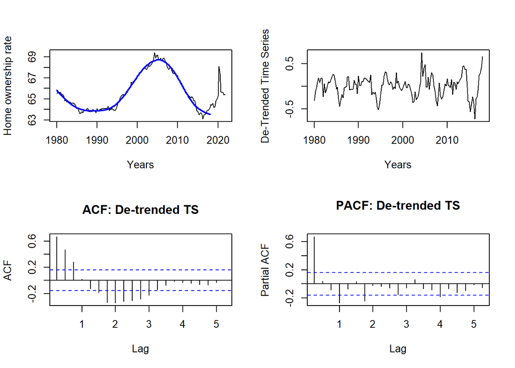

```r
time.pts = c(1:length(hosr[,"hosr"]))
time.pts = c(time.pts - min(time.pts))/max(time.pts)
x <- time.pts[1:153]
m_spl_org = gam(training[,"hosr"]~s(x))
m_spl_org.fit = fitted(m_spl_org)
m_spl_org.fit = ts(m_spl_org.fit,start=1980, freq=4)
resid.process = training[,"hosr"]-m_spl_org.fit
resid.process = ts(resid.process,start=1980, freq=4)
par(mfrow=c(2,2))
plot(ts_hosr,xlab="Years",ylab="Home ownership rate",type="l")
lines(m_spl_org.fit,lwd=2,col="blue")
plot(resid.process,xlab="Years",ylab="De-Trended Time Series",type="l")
acf(resid.process,main="ACF: De-trended TS")
pacf(resid.process,main="PACF: De-trended TS")
```

## order selection —AICC

```r
n = length(resid.process)
norder = 6
aicc <- data.frame(Inf,Inf,Inf,Inf)
names(aicc) <- c("p","d","q","aicc")
test_arima <- function(train,p,d,q,n){
  fit <-arima(train,order = c(p,d,q), method='ML')
  curr.aicc <- fit$aic-2*(p+q+1)+2*(p+q+1)*n/(n-p-q-2)
  df <- data.frame(p,d,q,curr.aicc)
  names(df) <- c("p","d","q","aicc")
  return(df)
}
for(p in 1:norder){
  for(d in 0:1){
    for(q in 1:norder){
      aicc = rbind(aicc,test_arima(resid.process,p,d,q,n))
    }
  }
}
aicc <- aicc[order(aicc$aicc),]
m1.orders = c(aicc$p[1],aicc$d[1],aicc$q[1])
```

fit ARMA model

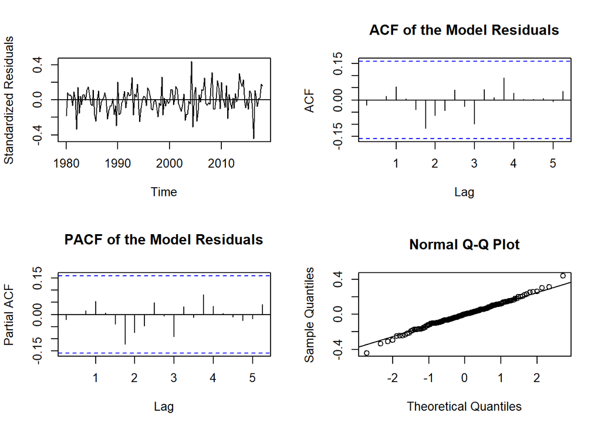

```r
m_arma_org = arima(resid.process,order = m1.orders, method='ML')
m_arma_org.res = resid(m_arma_org)
## Residual Analysis
par (mfrow=c(2,2))
plot(m_arma_org.res, ylab='Standardized Residuals')
abline(h=0)
acf(m_arma_org.res,main= 'ACF of the Model Residuals')
pacf(m_arma_org.res,main='PACF of the Model Residuals')
qqnorm(m_arma_org.res)
qqline(m_arma_org.res)
```

The de-trended time series shows that the trend has been removed. the residuals are normally distributed. The ACF and PACF plots show also that it is plausible that the de-trended time series is stationary.

trend estimation and ARMA log

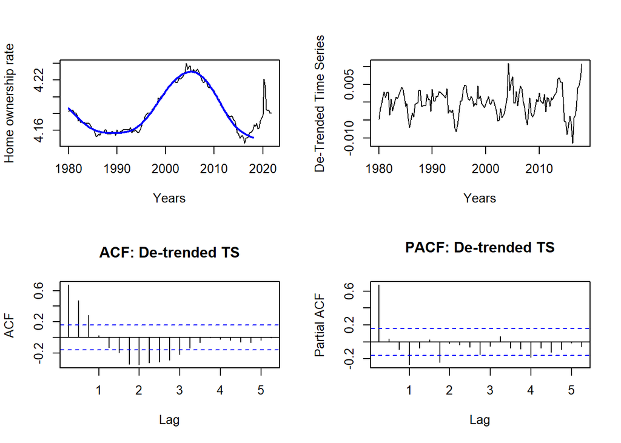

```r
time.pts = c(1:length(hosr_log[,"hosr"]))
time.pts = c(time.pts - min(time.pts))/max(time.pts)
x <- time.pts[1:153]
m_spl_log = gam(training_log[,"hosr"]~s(x))
m_spl_log.fit = fitted(m_spl_log)
m_spl_log.fit = ts(m_spl_log.fit,start=1980, freq=4)
resid.process = training_log[,"hosr"]-m_spl_log.fit
resid.process = ts(resid.process,start=1980, freq=4)
par(mfrow=c(2,2))
plot(ts_hosr_log,xlab="Years",ylab="Home ownership rate",type="l")
lines(m_spl_log.fit,lwd=2,col="blue")
plot(resid.process,xlab="Years",ylab="De-Trended Time Series",type="l")
acf(resid.process,main="ACF: De-trended TS")
pacf(resid.process,main="PACF: De-trended TS")
```

```r
n = length(resid.process)
norder = 6
aicc <- data.frame(Inf,Inf,Inf,Inf)
names(aicc) <- c("p","d","q","aicc")
test_arima <- function(train,p,d,q,n){
  fit <-arima(train,order = c(p,d,q), method='ML')
  curr.aicc <- fit$aic-2*(p+q+1)+2*(p+q+1)*n/(n-p-q-2)
  df <- data.frame(p,d,q,curr.aicc)
  names(df) <- c("p","d","q","aicc")
  return(df)
}
for(p in 1:norder){
  for(d in 0:1){
    for(q in 1:norder){
      aicc = rbind(aicc,test_arima(resid.process,p,d,q,n))
    }
  }
}
```

[output not shown]

```r
aicc <- aicc[order(aicc$aicc),]
m1.orders = c(aicc$p[1],aicc$d[1],aicc$q[1])
```

fit ARMA model log

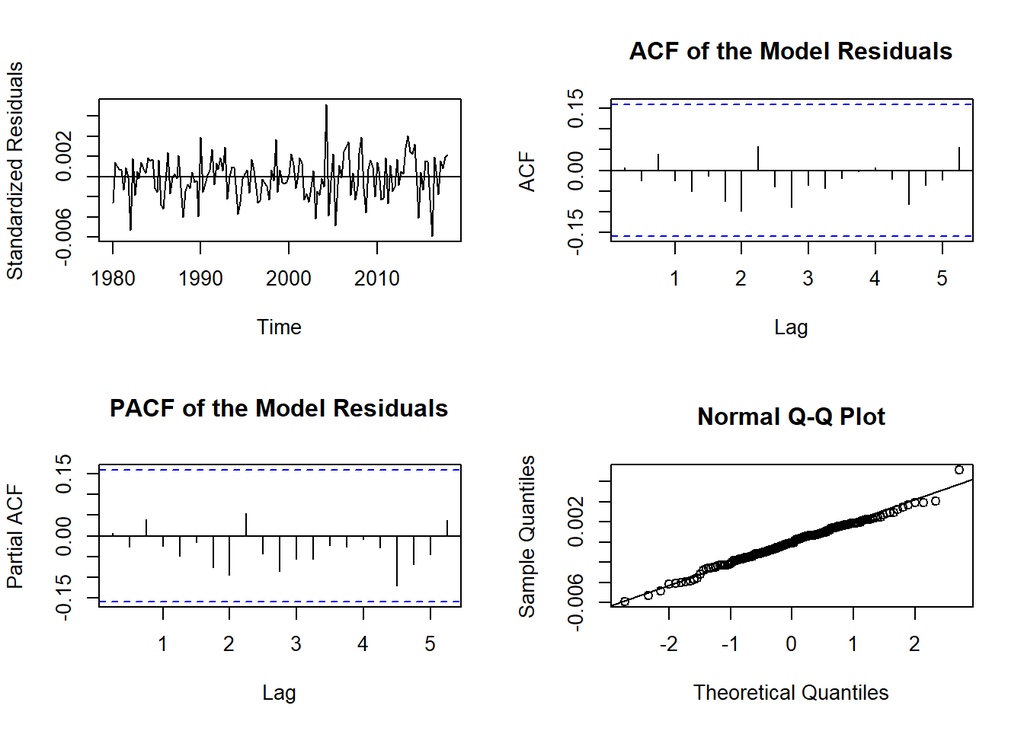

```r
m_arma_log = arima(resid.process,order = m1.orders, method='ML')
m_arma_log.res = resid(m_arma_log)
## Residual Analysis
par (mfrow=c(2,2))
plot(m_arma_log.res, ylab='Standardized Residuals')
abline(h=0)
acf(m_arma_log.res,main= 'ACF of the Model Residuals')
pacf(m_arma_log.res,main='PACF of the Model Residuals')
qqnorm(m_arma_log.res)
qqline(m_arma_log.res)
```

The de-trended time series shows that the trend has been removed. the residuals are normally distributed. The ACF and PACF plots show also that it is plausible that the de-trended time series is stationary.

## ARIMA model on original data

```r
n = length(training[,"hosr"])
norder = 6
aicc <- data.frame(Inf,Inf,Inf,Inf)
names(aicc) <- c("p","d","q","aicc")
test_arima <- function(train,p,d,q,n){
  fit <-arima(train,order = c(p,d,q), method='ML')
  curr.aicc <- fit$aic-2*(p+q+1)+2*(p+q+1)*n/(n-p-q-2)
  df <- data.frame(p,d,q,curr.aicc)
  names(df) <- c("p","d","q","aicc")
  return(df)
}
for(p in 1:norder){
  for(d in 0:1){
    for(q in 1:norder){
      possibleError <- tryCatch(
        aicc <- rbind(aicc,test_arima(training[,"hosr"],p,d,q,n)),
        error = function(e) e
      )
      if(inherits(possibleError,"error")) next
    }
  }
}
```

[output not shown]

```r
aicc <- aicc[order(aicc$aicc),]
m2.orders = c(aicc$p[1],aicc$d[1],aicc$q[1])
```

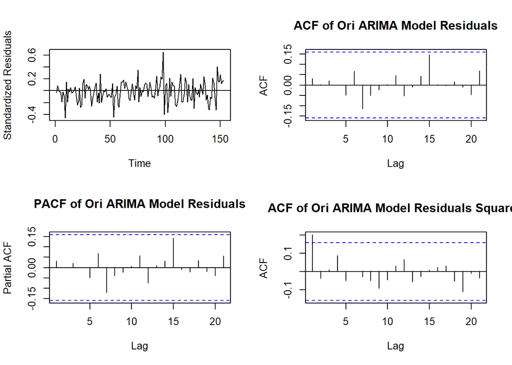

```r
m_arima_ori = arima(training[,"hosr"], order = m2.orders, method = "ML")
m_arima_ori.res = resid(m_arima_ori)
## Residual Analysis
par (mfrow=c(2,2))
plot(m_arima_ori.res, ylab='Standardized Residuals')
abline(h=0)
acf(m_arima_ori.res,main= 'ACF of Ori ARIMA Model Residuals')
pacf(m_arima_ori.res,main='PACF of Ori ARIMA Model Residuals')
acf(m_arima_ori.res^2,main= 'ACF of Ori ARIMA Model Residuals Squared')
```

```r
pacf(m_arima_ori.res^2,main='PACF of Ori ARIMA Model Residuals Squared')
qqnorm(m_arima_ori.res)
qqline(m_arima_ori.res)
Box.test(m_arima_ori$resid, lag = (aicc$p[1]+aicc$q[1]+1), type = "Box-Pierce", fitdf = (aicc$p[1]+aicc$q[1]))
```

```
##
##  Box-Pierce test
##
## data:  m_arima_ori$resid
## X-squared = 3.6666, df = 1, p-value = 0.05551
```

```r
Box.test(m_arima_ori$resid, lag = (aicc$p[1]+aicc$q[1]+1), type = "Ljung-Box", fitdf = (aicc$p[1]+aicc$q[1]))
```

```
##
##  Box-Ljung test
##
## data:  m_arima_ori$resid
## X-squared = 3.877, df = 1, p-value = 0.04895
```

[figure not shown]

## ARIMA model on log data

```r
n = length(training_log[,"hosr"])
norder = 6
aicc <- data.frame(Inf,Inf,Inf,Inf)
names(aicc) <- c("p","d","q","aicc")
for(p in 1:norder){
  for(d in 0:1){
    for(q in 1:norder){
      possibleError <- tryCatch(
        aicc <- rbind(aicc,test_arima(training_log[,"hosr"],p,d,q,n)),
        error = function(e) e
      )
      if(inherits(possibleError,"error")) next
    }
  }
}
aicc <- aicc[order(aicc$aicc),]
m2.orders = c(aicc$p[1],aicc$d[1],aicc$q[1])
```

```r
m_arima_log = arima(training_log[,"hosr"], order = m2.orders, method = "ML")
```

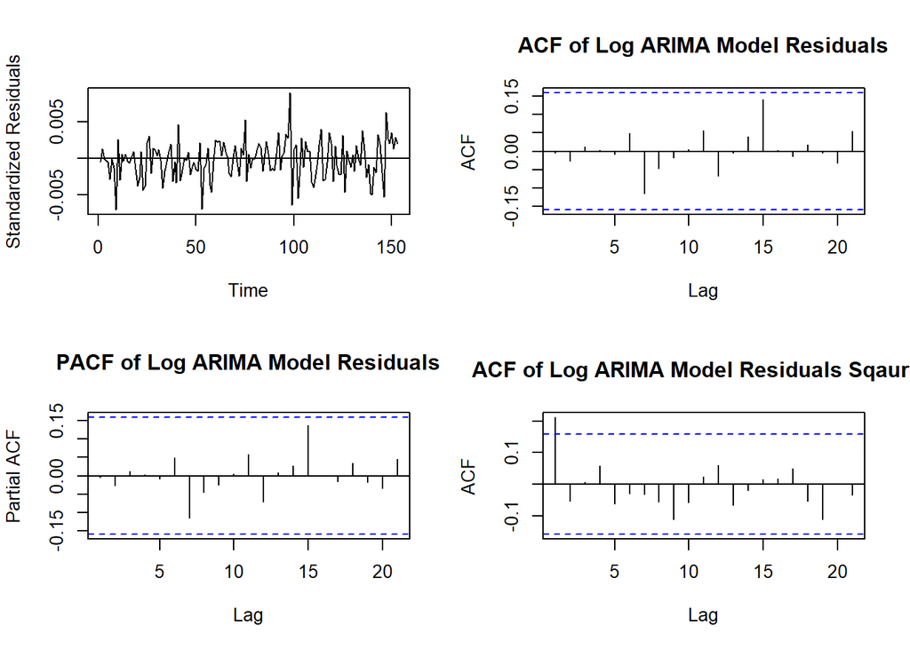

```r
m_arima_log.res = resid(m_arima_log)
## Residual Analysis
par (mfrow=c(2,2))
plot(m_arima_log.res, ylab='Standardized Residuals')
abline(h=0)
acf(m_arima_log.res,main= 'ACF of Log ARIMA Model Residuals')
pacf(m_arima_log.res,main='PACF of Log ARIMA Model Residuals')
acf(m_arima_log.res^2,main= 'ACF of Log ARIMA Model Residuals Sqaured')
```

```r
pacf(m_arima_log.res^2,main='PACF of Log ARIMA Model Residuals Sqaured')
qqnorm(m_arima_log.res)
qqline(m_arima_log.res)
Box.test(m_arima_log$resid, lag = (aicc$p[1]+aicc$q[1]+1), type = "Box-Pierce", fitdf = (aicc$p[1]+aicc$q[1]))
```

```
##
##  Box-Pierce test
##
## data:  m_arima_log$resid
## X-squared = 3.3632, df = 1, p-value = 0.06667
```

```r
Box.test(m_arima_log$resid, lag = (aicc$p[1]+aicc$q[1]+1), type = "Ljung-Box", fitdf = (aicc$p[1]+aicc$q[1]))
```

```
##
##  Box-Ljung test
##
## data:  m_arima_log$resid
## X-squared = 3.5805, df = 1, p-value = 0.05846
```

[figure not shown]

## var model org

```r
var_data_train <- cbind(ts_hosr,ts_icsa,ts_mspus,ts_permit)
var_data_train <- var_data_train[1:(n-15),]
VARselect(var_data_train, lag.max = 20)$selection
```

```
## AIC(n)  HQ(n)  SC(n) FPE(n)
##      2      2      2      2
```

```r
m_var_org=VAR(var_data_train, p=2)
summary(m_var_org$varresult$ts_hosr)
```

```
##
## Call:
## lm(formula = y ~ -1 + ., data = datamat)
##
## Residuals:
##      Min       1Q   Median       3Q      Max
## -0.54567 -0.09654  0.01291  0.11517  0.70385
##
## Coefficients:
##                Estimate Std. Error t value Pr(>|t|)
## ts_hosr.l1    9.284e-01  8.942e-02  10.383   <2e-16 ***
## ts_icsa.l1    9.209e-08  6.423e-07   0.143    0.886
## ts_mspus.l1  -2.738e-06  3.349e-06  -0.817    0.415
## ts_permit.l1  3.048e-04  1.929e-04   1.580    0.117
## ts_hosr.l2    6.821e-02  9.129e-02   0.747    0.456
## ts_icsa.l2   -4.648e-07  6.240e-07  -0.745    0.458
## ts_mspus.l2   2.434e-06  3.415e-06   0.713    0.477
## ts_permit.l2 -2.050e-04  2.034e-04  -1.008    0.315
## const         2.744e-01  1.087e+00   0.252    0.801
## ---
## Signif. codes:  0 '***' 0.001 '**' 0.01 '*' 0.05 '.' 0.1 ' ' 1
##
## Residual standard error: 0.1899 on 127 degrees of freedom
## Multiple R-squared:  0.9887, Adjusted R-squared:  0.988
## F-statistic:  1392 on 8 and 127 DF,  p-value: < 2.2e-16
```

```r
## Model Fitting: Restricted VAR
m_rs_var_org=restrict(m_var_org)
summary(m_rs_var_org$varresult$ts_hosr)
```

```
##
## Call:
## lm(formula = y ~ -1 + ., data = datares)
##
## Residuals:
##      Min       1Q   Median       3Q      Max
## -0.57962 -0.09752  0.00741  0.11430  0.63319
##
## Coefficients:
##               Estimate Std. Error t value Pr(>|t|)
## ts_hosr.l1   9.972e-01  8.526e-04 1169.66  < 2e-16 ***
## ts_permit.l1 1.287e-04  3.935e-05    3.27  0.00137 **
## ---
## Signif. codes:  0 '***' 0.001 '**' 0.01 '*' 0.05 '.' 0.1 ' ' 1
##
## Residual standard error: 0.1876 on 134 degrees of freedom
## Multiple R-squared:      1,  Adjusted R-squared:      1
## F-statistic: 8.372e+06 on 2 and 134 DF,  p-value: < 2.2e-16
```

residuals of var

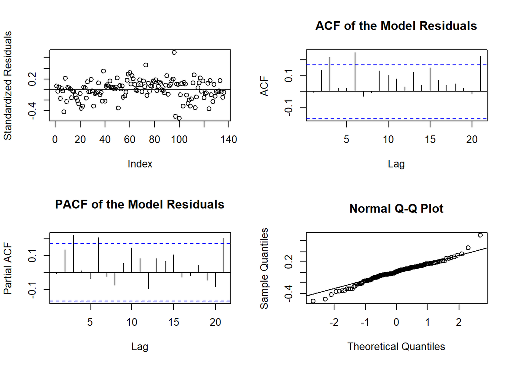

```r
m_var_org.res = resid(m_var_org)[,"ts_hosr"]
## Residual Analysis
par (mfrow=c(2,2))
plot(m_var_org.res, ylab='Standardized Residuals')
abline(h=0)
acf(m_var_org.res,main= 'ACF of the Model Residuals')
pacf(m_var_org.res,main='PACF of the Model Residuals')
qqnorm(m_var_org.res)
qqline(m_var_org.res)
```

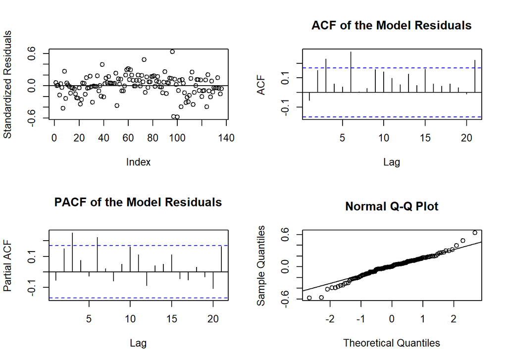

```r
m_rs_var_org.res = resid(m_rs_var_org)[,"ts_hosr"]
## Residual Analysis
par (mfrow=c(2,2))
plot(m_rs_var_org.res, ylab='Standardized Residuals')
abline(h=0)
acf(m_rs_var_org.res,main= 'ACF of the Model Residuals')
pacf(m_rs_var_org.res,main='PACF of the Model Residuals')
qqnorm(m_rs_var_org.res)
qqline(m_rs_var_org.res)
```

The residual is weakly stationary with few bars slightly outside of the significant band and the residual seems to be roughly normally distributed with few points at fat tails.

## var model log

```r
var_data_train <- cbind(ts_hosr_log,ts_icsa_log)
var_data_train <- var_data_train[1:(n-15),]
VARselect(var_data_train, lag.max = 20)$selection
```

```
## AIC(n)  HQ(n)  SC(n) FPE(n)
##      7      2      2      7
```

```r
m_var_log=VAR(var_data_train, p=2)
summary(m_var_log$varresult$ts_hosr)
```

```
##
## Call:
## lm(formula = y ~ -1 + ., data = datamat)
##
## Residuals:
##        Min         1Q     Median         3Q        Max
## -0.0072615 -0.0017503  0.0003572  0.0017995  0.0103540
##
## Coefficients:
##                  Estimate Std. Error t value Pr(>|t|)
## ts_hosr_log.l1  0.9839074  0.0875116  11.243   <2e-16 ***
## ts_icsa_log.l1 -0.0027359  0.0036993  -0.740    0.461
## ts_hosr_log.l2  0.0097120  0.0874820   0.111    0.912
## ts_icsa_log.l2 -0.0005668  0.0037022  -0.153    0.879
## const           0.0690259  0.0454332   1.519    0.131
## ---
## Signif. codes:  0 '***' 0.001 '**' 0.01 '*' 0.05 '.' 0.1 ' ' 1
##
## Residual standard error: 0.002905 on 131 degrees of freedom
## Multiple R-squared:  0.9881, Adjusted R-squared:  0.9877
## F-statistic:  2716 on 4 and 131 DF,  p-value: < 2.2e-16
```

```r
## Model Fitting: Restricted VAR
m_rs_var_log=restrict(m_var_log)
summary(m_rs_var_log$varresult$ts_hosr)
```

```
##
## Call:
## lm(formula = y ~ -1 + ., data = datares)
##
## Residuals:
##        Min         1Q     Median         3Q        Max
## -0.0075956 -0.0014567  0.0000907  0.0016281  0.0102296
##
## Coefficients:
##                 Estimate Std. Error t value Pr(>|t|)
## ts_hosr_log.l1 1.000e+00  5.985e-05   16707   <2e-16 ***
## ---
## Signif. codes:  0 '***' 0.001 '**' 0.01 '*' 0.05 '.' 0.1 ' ' 1
##
## Residual standard error: 0.002922 on 135 degrees of freedom
## Multiple R-squared:      1,  Adjusted R-squared:      1
## F-statistic: 2.791e+08 on 1 and 135 DF,  p-value: < 2.2e-16
```

residuals of var

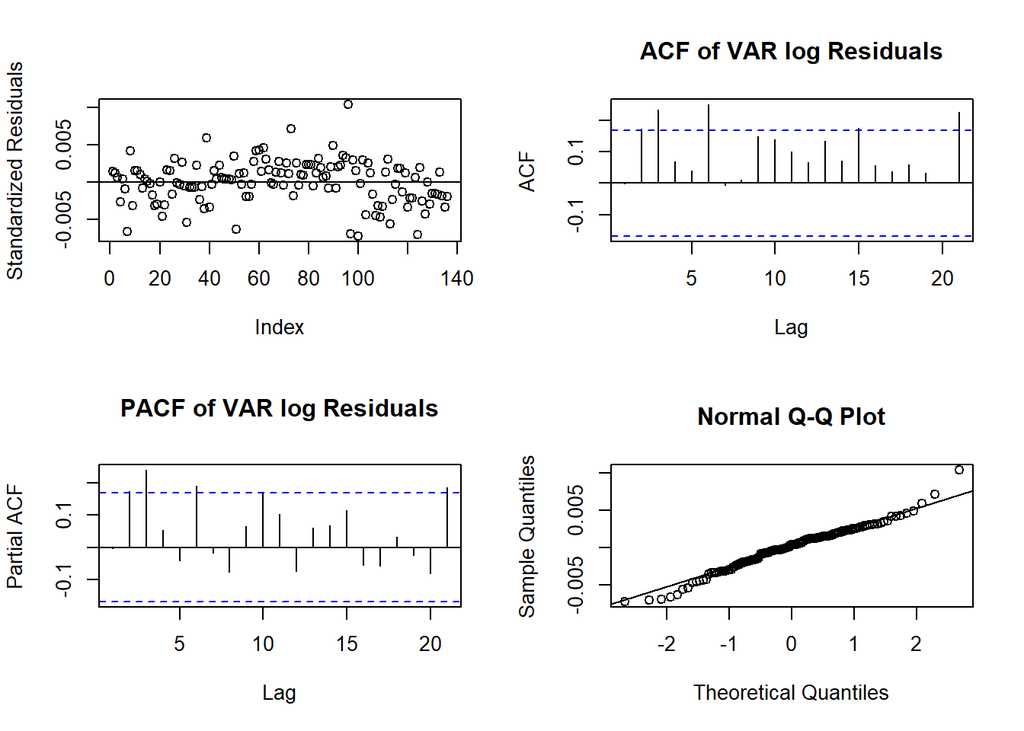

```r
m_var_log.res = resid(m_var_log)[,"ts_hosr_log"]
## Residual Analysis
par (mfrow=c(2,2))
plot(m_var_log.res, ylab='Standardized Residuals')
abline(h=0)
acf(m_var_log.res,main= 'ACF of VAR log Residuals')
pacf(m_var_log.res,main='PACF of VAR log Residuals')
qqnorm(m_var_log.res)
qqline(m_var_log.res)
```

```r
m_rs_var_log.res = resid(m_rs_var_log)[,"ts_hosr_log"]
arch.test(m_var_log)
```

```
##
##  ARCH (multivariate)
##
## data:  Residuals of VAR object m_var_log
## Chi-squared = 51.35, df = 45, p-value = 0.2389
```

```r
normality.test(m_var_log)
```

```
## $JB
##
##  JB-Test (multivariate)
##
## data:  Residuals of VAR object m_var_log
## Chi-squared = 7.1866, df = 4, p-value = 0.1263
##
##
## $Skewness
##
##  Skewness only (multivariate)
##
## data:  Residuals of VAR object m_var_log
## Chi-squared = 0.21051, df = 2, p-value = 0.9001
##
##
## $Kurtosis
##
##  Kurtosis only (multivariate)
##
## data:  Residuals of VAR object m_var_log
## Chi-squared = 6.9761, df = 2, p-value = 0.03056
```

```r
serial.test(m_var_log)
```

```
##
##  Portmanteau Test (asymptotic)
##
## data:  Residuals of VAR object m_var_log
## Chi-squared = 78.216, df = 56, p-value = 0.02659
```

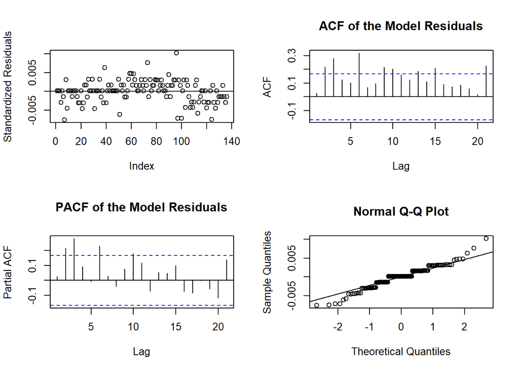

```r
## Residual Analysis
par (mfrow=c(2,2))
plot(m_rs_var_log.res, ylab='Standardized Residuals')
abline(h=0)
acf(m_rs_var_log.res,main= 'ACF of the Model Residuals')
pacf(m_rs_var_log.res,main='PACF of the Model Residuals')
qqnorm(m_rs_var_log.res)
qqline(m_rs_var_log.res)
```

The residual is weakly stationary with few bars slightly outside of the significant band and the residual seems to be roughly normally distributed with few points at fat tails.

For the restricted model, the residuals fall into few constant values and thus the QQ plots exhibits a zigzag pattern, which is weird

## varx org

```r
##Model Selection
VARselect(cbind(ts_hosr[1:153],ts_icsa[1:153]), lag.max = 20,exogen=data.frame(ts_mspus[1:153],ts_permit[1:153]))$selection
```

```
## AIC(n)  HQ(n)  SC(n) FPE(n)
##      7      2      2      7
```

```r
## Model Fitting: Unrestricted VAR
m_varx_org=VAR(data.frame(hosr=ts_hosr[1:153],icsa=ts_icsa[1:153]), p=2,exogen=data.frame(mspus=ts_mspus[1:153],permit=ts_permit[1:153]))
summary(m_varx_org)
```

```
##
## VAR Estimation Results:
## =========================
## Endogenous variables: hosr, icsa
## Deterministic variables: const
## Sample size: 151
## Log Likelihood: -1679.538
## Roots of the characteristic polynomial:
## 0.9843 0.5659 0.5659 0.01925
## Call:
## VAR(y = data.frame(hosr = ts_hosr[1:153], icsa = ts_icsa[1:153]),
##     p = 2, exogen = data.frame(mspus = ts_mspus[1:153], permit = ts_permit[1:153]))
##
##
## Estimation results for equation hosr:
## =====================================
## hosr = hosr.l1 + icsa.l1 + hosr.l2 + icsa.l2 + const + mspus + permit
##
##           Estimate Std. Error t value Pr(>|t|)
## hosr.l1  9.618e-01  8.344e-02  11.526   <2e-16 ***
## icsa.l1  3.942e-08  5.968e-07   0.066   0.9474
## hosr.l2  2.804e-02  8.388e-02   0.334   0.7387
## icsa.l2 -2.390e-07  5.512e-07  -0.434   0.6652
## const    5.653e-01  6.758e-01   0.836   0.4043
## mspus   -1.475e-07  3.203e-07  -0.461   0.6458
## permit   1.421e-04  5.538e-05   2.566   0.0113 *
## ---
## Signif. codes:  0 '***' 0.001 '**' 0.01 '*' 0.05 '.' 0.1 ' ' 1
##
##
## Residual standard error: 0.196 on 144 degrees of freedom
## Multiple R-Squared: 0.9881,  Adjusted R-squared: 0.9877
## F-statistic:  2001 on 6 and 144 DF,  p-value: < 2.2e-16
##
##
## Estimation results for equation icsa:
## =====================================
## icsa = hosr.l1 + icsa.l1 + hosr.l2 + icsa.l2 + const + mspus + permit
##
##           Estimate Std. Error t value Pr(>|t|)
```

[output cut: 11 more lines]

```
## Residual standard error: 21220 on 144 degrees of freedom
## Multiple R-Squared: 0.9287,  Adjusted R-squared: 0.9257
## F-statistic: 312.6 on 6 and 144 DF,  p-value: < 2.2e-16
##
##
##
## Covariance matrix of residuals:
##            hosr       icsa
## hosr    0.03842 -1.459e+02
## icsa -145.92203  4.502e+08
##
## Correlation matrix of residuals:
##          hosr     icsa
## hosr  1.00000 -0.03509
## icsa -0.03509  1.00000
```

```r
## Model Fitting: Restricted VAR
m_rs_varx_org=restrict(m_varx_org)
summary(m_rs_varx_org)
```

```
##
## VAR Estimation Results:
## =========================
## Endogenous variables: hosr, icsa
## Deterministic variables: const
## Sample size: 151
## Log Likelihood: -1680.805
## Roots of the characteristic polynomial:
## 0.9968 0.5726 0.5726     0
## Call:
## VAR(y = data.frame(hosr = ts_hosr[1:153], icsa = ts_icsa[1:153]),
##     p = 2, exogen = data.frame(mspus = ts_mspus[1:153], permit = ts_permit[1:153]))
##
##
## Estimation results for equation hosr:
## =====================================
## hosr = hosr.l1 + permit
##
##          Estimate Std. Error  t value Pr(>|t|)
## hosr.l1 9.968e-01  8.659e-04 1151.073  < 2e-16 ***
## permit  1.501e-04  4.039e-05    3.716 0.000286 ***
## ---
## Signif. codes:  0 '***' 0.001 '**' 0.01 '*' 0.05 '.' 0.1 ' ' 1
##
##
## Residual standard error: 0.194 on 149 degrees of freedom
## Multiple R-Squared:     1,   Adjusted R-squared:     1
## F-statistic: 8.644e+06 on 2 and 149 DF,  p-value: < 2.2e-16
##
##
## Estimation results for equation icsa:
## =====================================
## icsa = icsa.l1 + hosr.l2 + icsa.l2 + const + mspus + permit
##
##           Estimate Std. Error t value Pr(>|t|)
## icsa.l1  1.070e+00  6.449e-02  16.597  < 2e-16 ***
## hosr.l2  7.110e+03  1.294e+03   5.495 1.71e-07 ***
## icsa.l2 -3.278e-01  5.950e-02  -5.509 1.60e-07 ***
## const   -2.895e+05  7.296e+04  -3.968 0.000113 ***
## mspus   -1.930e-01  3.451e-02  -5.592 1.08e-07 ***
## permit  -3.706e+01  5.885e+00  -6.297 3.41e-09 ***
## ---
## Signif. codes:  0 '***' 0.001 '**' 0.01 '*' 0.05 '.' 0.1 ' ' 1
##
##
## Residual standard error: 21180 on 145 degrees of freedom
## Multiple R-Squared: 0.997,   Adjusted R-squared: 0.9968
## F-statistic:  7957 on 6 and 145 DF,  p-value: < 2.2e-16
##
##
##
## Covariance matrix of residuals:
##            hosr       icsa
## hosr    0.03894 -1.376e+02
## icsa -137.64308  4.516e+08
##
## Correlation matrix of residuals:
##          hosr     icsa
## hosr  1.00000 -0.03282
## icsa -0.03282  1.00000
```

residuals of varx

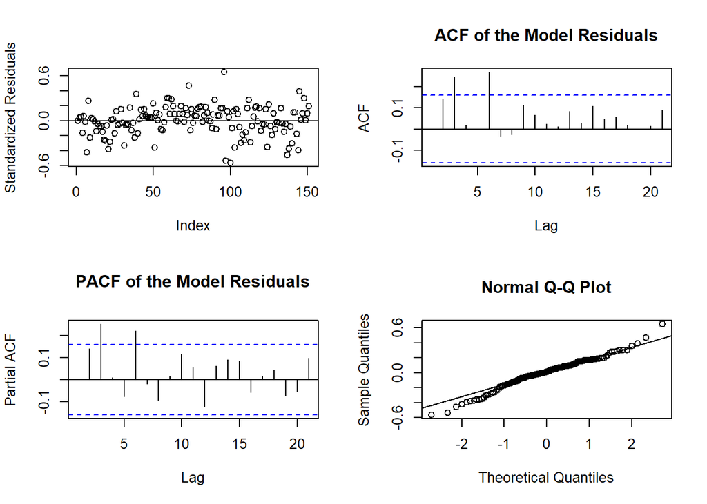

```r
m_varx_org.res = resid(m_varx_org)[,"hosr"]
## Residual Analysis
par (mfrow=c(2,2))
plot(m_varx_org.res, ylab='Standardized Residuals')
abline(h=0)
acf(m_varx_org.res,main= 'ACF of the Model Residuals')
pacf(m_varx_org.res,main='PACF of the Model Residuals')
qqnorm(m_varx_org.res)
qqline(m_varx_org.res)
```

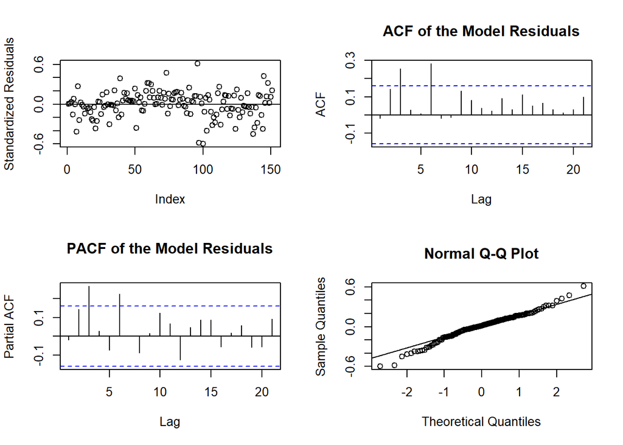

```r
m_rs_varx_org.res = resid(m_rs_varx_org)[,"hosr"]
## Residual Analysis
par (mfrow=c(2,2))
plot(m_rs_varx_org.res, ylab='Standardized Residuals')
abline(h=0)
acf(m_rs_varx_org.res,main= 'ACF of the Model Residuals')
pacf(m_rs_varx_org.res,main='PACF of the Model Residuals')
qqnorm(m_rs_varx_org.res)
qqline(m_rs_varx_org.res)
```

## ARIMAX on original data

```r
columns = c("MSPUS","PERMIT","ICSA")
x_reg = training[, columns]
y = training[, "hosr"]
m_arimax_ori = auto.arima(y, xreg = as.matrix(x_reg))
m_arimax_ori
```

```
## Series: y
## Regression with ARIMA(0,1,0) errors
##
## Coefficients:
##       MSPUS  PERMIT  ICSA
##       0e+00   1e-04     0
## s.e.  2e-04   0e+00     0
##
## sigma^2 = 0.04081:  log likelihood = 29
## AIC=-49.99   AICc=-49.72   BIC=-37.89
```

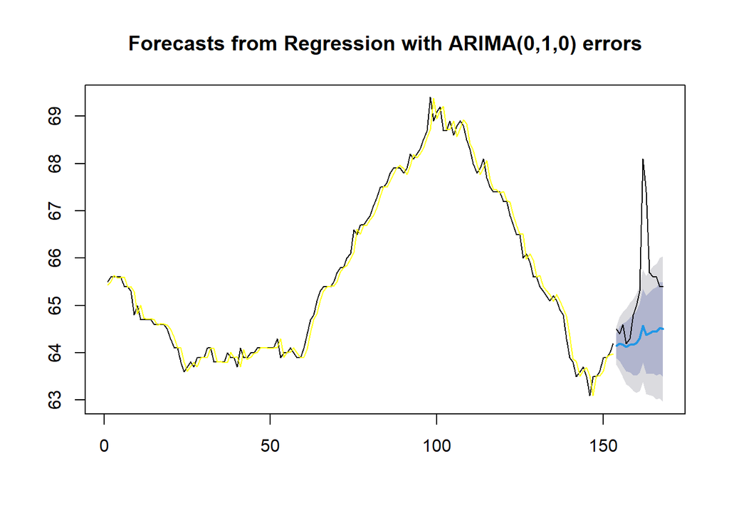

```r
m_arimax_ori_pred = forecast(m_arimax_ori, xreg = as.matrix(testing[, columns]))
# plot
plot(m_arimax_ori_pred)
lines(fitted(m_arimax_ori), col="yellow")
lines(c(154:168), testing[, "hosr"])
```

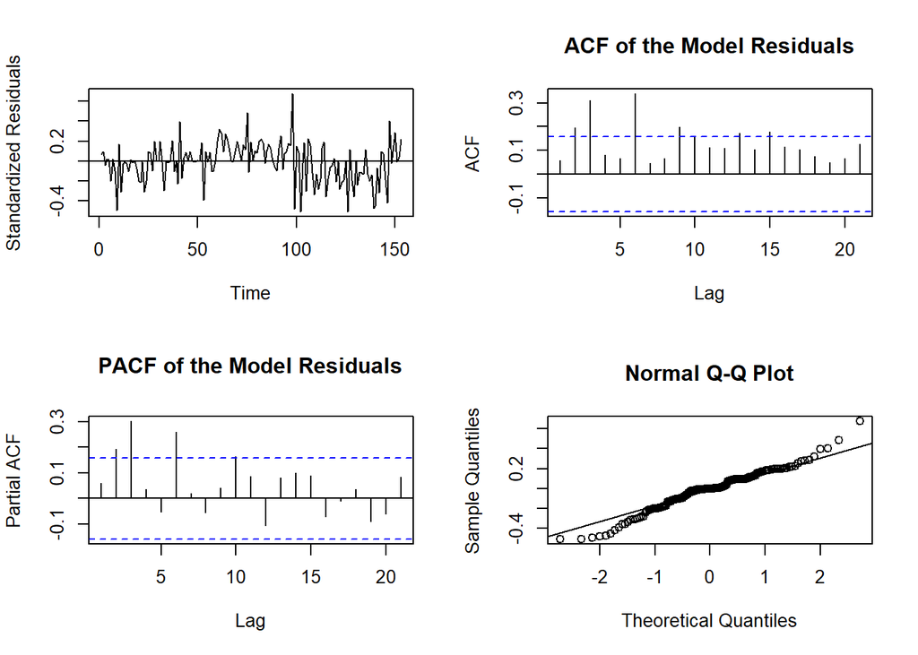

```r
m_arimax_ori.res = m_arimax_ori_pred$residuals
## Residual Analysis
par (mfrow=c(2,2))
plot(m_arimax_ori.res, ylab='Standardized Residuals')
abline(h=0)
acf(m_arimax_ori.res,main= 'ACF of the Model Residuals')
pacf(m_arimax_ori.res,main='PACF of the Model Residuals')
qqnorm(m_arimax_ori.res)
qqline(m_arimax_ori.res)
```

```r
Box.test(m_arimax_ori$resid, lag = 1, type = "Box-Pierce", fitdf = 1)
```

```
##
##  Box-Pierce test
##
## data:  m_arimax_ori$resid
## X-squared = 0.51871, df = 0, p-value < 2.2e-16
```

```r
Box.test(m_arimax_ori$resid, lag = 1, type = "Ljung-Box", fitdf = 1)
```

```
##
##  Box-Ljung test
##
## data:  m_arimax_ori$resid
## X-squared = 0.52895, df = 0, p-value < 2.2e-16
```

## ARIMAX on log data

```r
columns = c("ICSA")
x_reg = training_log[, columns]
y = training_log[, "hosr"]
m_arimax_log = auto.arima(y, xreg = as.matrix(x_reg))
m_arimax_log
```

```
## Series: y
## Regression with ARIMA(2,1,1) errors
##
## Coefficients:
##          ar1     ar2      ma1     xreg
##       0.7228  0.2011  -0.7738  -0.0023
## s.e.  0.1189  0.0892   0.1003   0.0032
##
## sigma^2 = 8.416e-06:  log likelihood = 675.31
## AIC=-1340.63   AICc=-1340.22   BIC=-1325.51
```

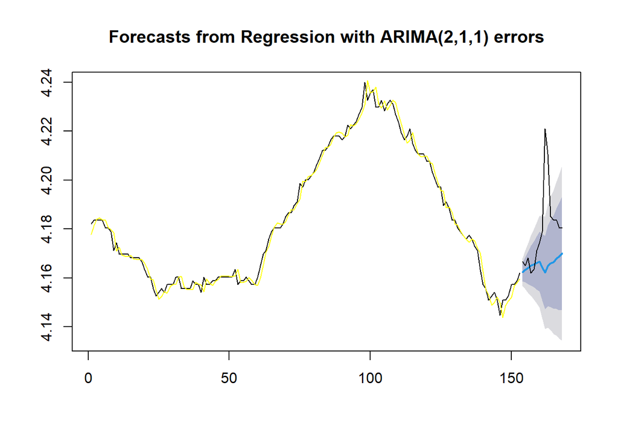

```r
m_arimax_log_pred = forecast(m_arimax_log, xreg = as.matrix(testing_log[, columns]))
# plot
plot(m_arimax_log_pred)
lines(fitted(m_arimax_log), col="yellow")
lines(c(154:168), testing_log[, "hosr"])
```

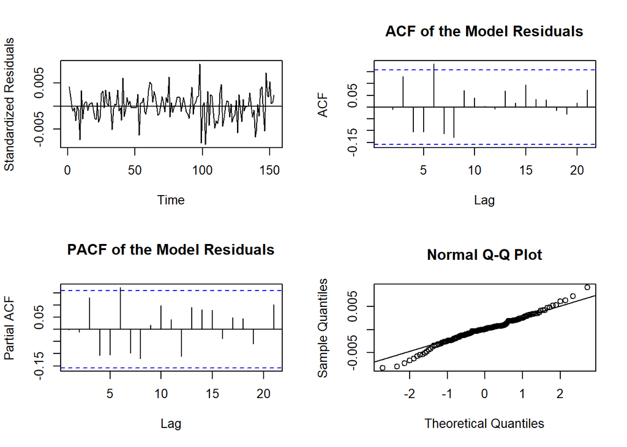

```r
m_arimax_log.res = m_arimax_log_pred$residuals
## Residual Analysis
par (mfrow=c(2,2))
plot(m_arimax_log.res, ylab='Standardized Residuals')
abline(h=0)
acf(m_arimax_log.res,main= 'ACF of the Model Residuals')
pacf(m_arimax_log.res,main='PACF of the Model Residuals')
qqnorm(m_arimax_log.res)
qqline(m_arimax_log.res)
```

```r
Box.test(m_arimax_log$resid, lag = 4, type = "Box-Pierce", fitdf = 4)
```

```
##
##  Box-Pierce test
##
## data:  m_arimax_log$resid
## X-squared = 4.3462, df = 0, p-value < 2.2e-16
```

```r
Box.test(m_arimax_log$resid, lag = 4, type = "Ljung-Box", fitdf = 4)
```

```
##
##  Box-Ljung test
##
## data:  m_arimax_log$resid
## X-squared = 4.5028, df = 0, p-value < 2.2e-16
```

## prediction

gam+arma org

```r
n = length(time.pts)
nfit=n-15
newdata = data.frame(x=time.pts[(nfit+1):n])
gam.pred= predict(m_spl_org,newdata = newdata,interval=c("prediction"))
outpredresid = predict(m_arma_org,n.ahead=15)$pred
outpredresid.se = predict(m_arma_org,n.ahead=15)$se
## Add up the predictions
m_gam_arma_org.pred = outpredresid+gam.pred
m_gam_arma_org.ubound= m_gam_arma_org.pred + 1.96 * outpredresid.se
m_gam_arma_org.lbound=m_gam_arma_org.pred - 1.96 * outpredresid.se
```

gam+arma log

```r
n = length(time.pts)
nfit=n-15
newdata = data.frame(x=time.pts[(nfit+1):n])
gam.pred= predict(m_spl_log,newdata = newdata,interval=c("prediction"))
outpredresid = predict(m_arma_log,n.ahead=15)$pred
outpredresid.se=predict(m_arma_log,n.ahead=15)$se
## Add up the predictions
m_gam_arma_log.pred = exp(outpredresid+gam.pred)
m_gam_arma_log.ubound=exp(outpredresid+gam.pred + 1.96 * outpredresid.se)
m_gam_arma_log.lbound=exp(outpredresid+gam.pred - 1.96 * outpredresid.se)
```

var model org

```r
m_var_org.pred = predict(m_var_org,n.ahead=15)$fcst$ts_hosr[,1]
m_var_org.pred.lbound=predict(m_var_org,n.ahead=15)$fcst$ts_hosr[,2]
m_var_org.pred.ubound=predict(m_var_org,n.ahead=15)$fcst$ts_hosr[,3]
m_rs_var_org.pred = predict(m_rs_var_org,n.ahead=15)$fcst$ts_hosr[,1]
m_rs_var_org.pred.lbound=predict(m_rs_var_org,n.ahead=15)$fcst$ts_hosr[,2]
m_rs_var_org.pred.ubound=predict(m_rs_var_org,n.ahead=15)$fcst$ts_hosr[,3]
```

var model log

```r
m_var_log.pred = exp(predict(m_var_log,n.ahead=15)$fcst$ts_hosr[,1])
m_var_log.pred.lbound=exp(predict(m_var_log,n.ahead=15)$fcst$ts_hosr[,2])
m_var_log.pred.ubound=exp(predict(m_var_log,n.ahead=15)$fcst$ts_hosr[,3])
m_rs_var_log.pred = exp(predict(m_rs_var_log,n.ahead=15)$fcst$ts_hosr[,1])
m_rs_var_log.pred.lbound=exp(predict(m_rs_var_log,n.ahead=15)$fcst$ts_hosr[,2])
m_rs_var_log.pred.ubound=exp(predict(m_rs_var_log,n.ahead=15)$fcst$ts_hosr[,3])
```

varx model org

```r
x = data.frame(mspus=ts_mspus[154:168],permit=ts_permit[154:168])
m_varx_org.pred = predict(m_varx_org,n.ahead=15,dumvar=x)$fcst$hosr[,1]
m_varx_org.pred.lbound = predict(m_varx_org,n.ahead=15,dumvar=x)$fcst$hosr[,2]
m_varx_org.pred.ubound = predict(m_varx_org,n.ahead=15,dumvar=x)$fcst$hosr[,3]
m_rs_varx_org.pred = predict(m_rs_varx_org,n.ahead=15,dumvar=x)$fcst$hosr[,1]
m_rs_varx_org.pred.lbound = predict(m_rs_varx_org,n.ahead=15,dumvar=x)$fcst$hosr[,2]
m_rs_varx_org.pred.ubound = predict(m_rs_varx_org,n.ahead=15,dumvar=x)$fcst$hosr[,3]
```

ARIMA

```r
m_arima_ori_pred = predict(m_arima_ori,n.ahead=15)
m_arima_ori_pred.pred = m_arima_ori_pred$pred
m_arima_ori_pred.ubound = m_arima_ori_pred.pred+1.96*m_arima_ori_pred$se
m_arima_ori_pred.lbound = m_arima_ori_pred.pred-1.96*m_arima_ori_pred$se
m_arima_log_pred = predict(m_arima_log, n.ahead=15)
m_arima_log_pred.pred = exp(m_arima_log_pred$pred)
m_arima_log_pred.ubound = exp(m_arima_log_pred$pred+1.96*m_arima_log_pred$se)
m_arima_log_pred.lbound = exp(m_arima_log_pred$pred-1.96*m_arima_log_pred$se)
```

ARIMAX

```r
m_arimax_ori_pred.pred = data.frame(m_arimax_ori_pred)[,"Point.Forecast"]
m_arimax_ori_pred.ubound = data.frame(m_arimax_ori_pred)[, "Hi.95"]
m_arimax_ori_pred.lbound = data.frame(m_arimax_ori_pred)[, "Lo.95"]
m_arimax_log_pred.pred = exp(data.frame(m_arimax_log_pred)[,"Point.Forecast"])
m_arimax_log_pred.ubound = exp(data.frame(m_arimax_log_pred)[, "Hi.95"])
m_arimax_log_pred.lbound = exp(data.frame(m_arimax_log_pred)[, "Lo.95"])
```